# Assignment 4: Neural Nets & Deep Learning

Zervaan Borok

2/20/2022

# Part 2 (a)

### Libraries

```r
# Core Tidyverse
library(tidyverse)
library(ggplot2)
library(glue)
library(forcats)

# Time Series
library(timetk)
library(tidyquant)
library(tibbletime)

# Visualization
library(cowplot)

# Preprocessing
library(recipes)

# Sampling / Accuracy
library(rsample)
library(yardstick)

# Modeling
library(keras)
library(tensorflow)
set_random_seed(42)
library(tfruns)
library(caret)
library(scales)
```

### Data

```r
aapl <- read_csv("C:\\Users\\zerva\\Documents\\AM11\\AAPL.csv")
aapl$Volume[aapl$Volume == 0] <- median(aapl$Volume)
head(aapl)
```

```
## # A tibble: 6 x 7
##   Date        Open  High   Low Close `Adj Close`    Volume
##   <date>     <dbl> <dbl> <dbl> <dbl>       <dbl>     <dbl>
## 1 1980-12-12 0.128 0.129 0.128 0.128      0.100  469033600
## 2 1980-12-15 0.122 0.122 0.122 0.122      0.0952 175884800
## 3 1980-12-16 0.113 0.113 0.113 0.113      0.0882 105728000
## 4 1980-12-17 0.116 0.116 0.116 0.116      0.0904  86441600
## 5 1980-12-18 0.119 0.119 0.119 0.119      0.0930  73449600
## 6 1980-12-19 0.126 0.127 0.126 0.126      0.0987  48630400
```

### Plot

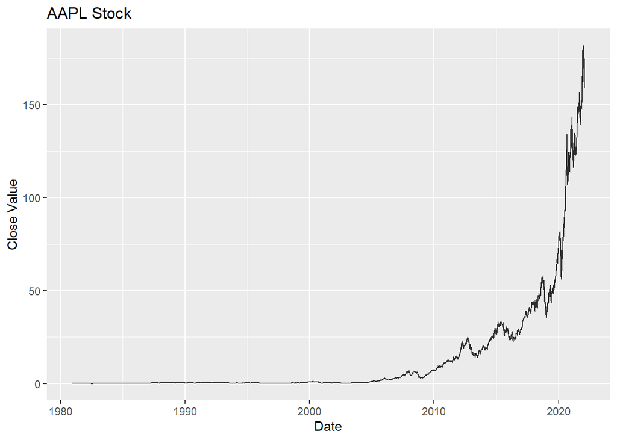

```r
ggplot(aapl, aes(x = Date, y = Close, group = 1)) +
  geom_line(color = "black", alpha = 0.8) +
  #scale_x_discrete(breaks = levels(aapl$Date)[floor(seq(1, nlevels(aapl$Date),length.out = 5))]) +
  labs(x = "Date", y = "Close Value", title = "AAPL Stock")
```

### Normalize the Data

Better performance for LSTM

```r
rec_obj <- recipe(Close ~ Close + Date, aapl) %>%
    step_sqrt(Close) %>%
    step_center(Close) %>%
    step_scale(Close) %>%
    prep()

aapl_normalized <- bake(rec_obj, aapl)

#keep centers for denormalization later
center_history <- rec_obj$steps[[2]]$means["Close"]
scale_history  <- rec_obj$steps[[3]]$sds["Close"]

c("center" = center_history, "scale" = scale_history)
```

```
## center.Close  scale.Close
##     2.331835     2.826167
```

```r
aapl_trn <- aapl_normalized[1:8000,] #training
aapl_val <- aapl_normalized[8001:9000,] #validation
aapl_test <- aapl_normalized[9001:10372,] #test for deletion
```

### Reshaping the Data

```r
n_inputs <- 3 #number of inputs in the RNN e.g. 1st it. use first 10 days to predict the 11th
n_predictions <- 1
batch_size <- 10 #number of batches that you give. large the model is faster -- parmeter
```

### Functions

```r
build_windowed_matrix <- function(data, timesteps) { #tranforms data into the  windows of 4+1) if you have 14K rows this produce a matric of 14K x 5
  t(sapply(1:(length(data) - timesteps + 1), function(x)
    data[x:(x + timesteps - 1)]))
}

reshape_3D <- function(df){ #to do it 14kx5x1 since this is required by keras. If it was multivariate (n) it should be  14kx5xn!!!
  dim(df) <- c(dim(df)[1], dim(df)[2], 1)
  df
}

get_x <- function(mtx, n_inputs, batch_size){#for each row gets the the x's (4 in number)
  mtx <- mtx[, 1:n_inputs]
  mtx <- mtx[1:(nrow(mtx) %/% batch_size * batch_size), ]
  reshape_3D(mtx)
}

get_y <- function(mtx, n_inputs, n_predictions, batch_size) {#for each row gets the the y (5th element) + put them in 3D
  mtx <- mtx[, (n_inputs+1):(n_inputs+n_predictions), drop=FALSE]
  mtx <- mtx[1:(nrow(mtx) %/% batch_size * batch_size), , drop=FALSE]
  if(n_predictions==1){
    dim(mtx) <- c(length(mtx)[1], 1)
  }
  reshape_3D(mtx)
}
```

### Extract ‘Close’ Values

Extract close values and disregard dates

```r
trn <- aapl_trn %>% select(Close) %>% pull() #into  vector
val <- aapl_val %>% select(Close) %>% pull()
test <- aapl_test %>% select(Close) %>% pull()
```

### Build matrices

actually using the functions that I defined above

```r
trn_mtx <- build_windowed_matrix(trn, n_inputs+n_predictions)
val_mtx <- build_windowed_matrix(val, n_inputs+n_predictions)
test_mtx <- build_windowed_matrix(test, n_inputs+n_predictions)

X_train <- get_x(trn_mtx, n_inputs, batch_size)
Y_train <- get_y(trn_mtx, n_inputs, n_predictions, batch_size)
X_val <- get_x(val_mtx, n_inputs, batch_size)
Y_val <- get_y(val_mtx, n_inputs, n_predictions, batch_size)
X_test <- get_x(test_mtx, n_inputs, batch_size)
Y_test <- get_y(test_mtx, n_inputs, n_predictions, batch_size)
```

### Build model

```r
model <- keras_model_sequential()

model %>%
  layer_lstm(  #lstm with 32 units in each cell
    units = 32,
    batch_input_shape = c(batch_size, n_inputs, 1)
  )

model %>%
  layer_dense(units = 1)

model %>%
  compile(
    loss = 'mean_squared_error',
    optimizer = 'sgd',
    metrics = list("mean_squared_error")
  )
```

```r
callbacks <- list(#stop criterion depends on if the network is not learning any more...stop the model from training after 5 epochs if there is no learning
  callback_early_stopping(patience = 5)
)
```

```r
history <- model %>% fit(
  x = X_train,
  y = Y_train,
  validation_data = list(X_val, Y_val),
  batch_size = batch_size,
  epochs = 100,
  callbacks = callbacks
  ,verbose = 0
)
```

### Predictions

```r
pred_test <- model %>%
  predict(X_test, batch_size = batch_size)
# de-normalize to original scale
pred_test <- (pred_test * scale_history + center_history)^2 #denormalization
```

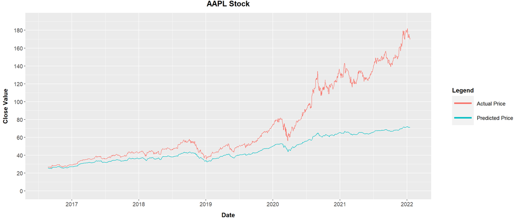

```r
ggplot(aapl[(9001+n_inputs):(9000+n_inputs+dim(pred_test)[1]),], aes(x = Date, y = Close, group = 1)) + geom_line(aes(color = "Actual Price")) +
  geom_line(aes(y = pred_test, color = "Predicted Price")) +
  labs(x = "Date", y = "Close Value", colour = "Legend") +
  ggtitle("AAPL Stock") +
                        theme(
                        plot.title = element_text(size = 15, face = "bold", hjust = 0.5, vjust = 2.5),
                        axis.title.x = element_text(size = 12, face = "bold", margin = margin(t = 10)),
                        axis.title.y = element_text(size = 12, face = "bold", margin = margin(r = 10)),
                        axis.text.x = element_text(size = 11),
                        axis.text.y = element_text(size = 11),
                        legend.title = element_text(size = 12, face = "bold"),
                        legend.text = element_text(size = 10.5),
                        legend.key.height = unit(1, 'cm'),
                        legend.key.width = unit(1.5, 'cm'),
                        legend.position = "right", legend.margin=margin(l = 30)) +
                        guides(color = guide_legend(override.aes = list(size = 1.5))) +
  scale_x_date(date_breaks = "1 year", date_labels = "%Y", limits = c(as.Date("08/01/16", "%m/%d/%y"),as.Date("02/01/22", "%m/%d/%y"))) +
  scale_y_continuous(breaks = scales::pretty_breaks(n = 10), limits = c(0.00, 190))
```

```r
R2(pred_test, aapl$Close[9004:10363])
```

```
##           [,1]
## [1,] 0.9574976
```

## Using High as well as Close Price

### Normalize the Data

Better performance for LSTM

```r
rec_obj_1 <- recipe(Close ~ Close + Date + High, aapl) %>%
    step_sqrt(Close) %>%
    step_center(Close) %>%
    step_scale(Close) %>%
    step_sqrt(High) %>%
    step_center(High) %>%
    step_scale(High) %>%
    prep()

aapl_normalized_1 <- bake(rec_obj_1, aapl)

#keep centers for denormalization later
center_history_1 <- rec_obj_1$steps[[2]]$means["Close"]
scale_history_1  <- rec_obj_1$steps[[3]]$sds["Close"]

center_history_11 <- rec_obj_1$steps[[5]]$means["High"]
scale_history_11  <- rec_obj_1$steps[[6]]$sds["High"]

c("center" = center_history_1, "scale" = scale_history_1
  ,"center" = center_history_11, "scale" = scale_history_11
  )
```

```
## center.Close  scale.Close  center.High   scale.High
##     2.331835     2.826167     2.345395     2.839499
```

```r
aapl_trn_1 <- aapl_normalized_1[1:8000,] #training
aapl_val_1 <- aapl_normalized_1[8001:9000,] #validation
aapl_test_1 <- aapl_normalized_1[9001:10372,] #test for deletion
```

### Reshaping the Data

```r
n_inputs <- 3 #number of inputs in the RNN e.g. 1st it. use first 10 days to predict the 11th
n_predictions <- 1
batch_size <- 10 #number of batches that you give. large the model is faster -- parmeter
```

### Functions

```r
build_windowed_matrix <- function(data, timesteps) { #tranforms data into the  windows of 4+1) if you have 14K rows this produce a matric of 14K x 5
  t(sapply(1:(length(data) - timesteps + 1), function(x)
    data[x:(x + timesteps - 1)]))
}

reshape_3D <- function(df){ #to do it 14kx5x1 since this is required by keras. If it was multivariate (n) it should be  14kx5xn!!!
  dim(df) <- c(dim(df)[1], dim(df)[2], 1)
  df
}

get_x <- function(mtx, n_inputs, batch_size){#for each row gets the the x's (4 in number)
  mtx <- mtx[, 1:n_inputs]
  mtx <- mtx[1:(nrow(mtx) %/% batch_size * batch_size), ]
  reshape_3D(mtx)
}

get_y <- function(mtx, n_inputs, n_predictions, batch_size) {#for each row gets the the y (5th element) + put them in 3D
  mtx <- mtx[, (n_inputs+1):(n_inputs+n_predictions), drop=FALSE]
  mtx <- mtx[1:(nrow(mtx) %/% batch_size * batch_size), , drop=FALSE]
  if(n_predictions==1){
    dim(mtx) <- c(length(mtx)[1], 1)
  }
  reshape_3D(mtx)
}
```

### Extract ‘Close’ Values

Extract close values and disregard dates

```r
trn_1 <- aapl_trn_1 %>% select(Close) %>% pull() #into  vector
val_1 <- aapl_val_1 %>% select(Close) %>% pull()
test_1 <- aapl_test_1 %>% select(Close) %>% pull()

trn_11 <- aapl_trn_1 %>% select(High) %>% pull() #into  vector
val_11 <- aapl_val_1 %>% select(High) %>% pull()
test_11 <- aapl_test_1 %>% select(High) %>% pull()
```

### Build matrices

actually using the functions that I defined above

```r
trn_mtx_1 <- build_windowed_matrix(trn_1, n_inputs+n_predictions)
val_mtx_1 <- build_windowed_matrix(val_1, n_inputs+n_predictions)
test_mtx_1 <- build_windowed_matrix(test_1, n_inputs+n_predictions)

trn_mtx_11 <- build_windowed_matrix(trn_11, n_inputs+n_predictions)
val_mtx_11 <- build_windowed_matrix(val_11, n_inputs+n_predictions)
test_mtx_11 <- build_windowed_matrix(test_11, n_inputs+n_predictions)

trn_mtx_111 <- cbind(trn_mtx_1, trn_mtx_11)
val_mtx_111 <- cbind(val_mtx_1, val_mtx_11)
test_mtx_111 <- cbind(test_mtx_1, test_mtx_11)


X_train_1 <- get_x(trn_mtx_111, n_inputs, batch_size)
Y_train_1 <- get_y(trn_mtx_111, n_inputs, n_predictions, batch_size)
X_val_1 <- get_x(val_mtx_111, n_inputs, batch_size)
Y_val_1 <- get_y(val_mtx_111, n_inputs, n_predictions, batch_size)
X_test_1 <- get_x(test_mtx_111, n_inputs, batch_size)
Y_test_1 <- get_y(test_mtx_111, n_inputs, n_predictions, batch_size)
```

### Build model

```r
model_1 <- keras_model_sequential()

model_1 %>%
  layer_lstm(  #lstm with 32 units in each cell
    units = 32,
    batch_input_shape = c(batch_size, n_inputs, 1)
  )

model_1 %>%
  layer_dense(units = 1)

model_1 %>%
  compile(
    loss = 'mean_squared_error',
    optimizer = 'sgd',
    metrics = list("mean_squared_error")
  )
```

```r
callbacks <- list(#stop criterion depends on if the network is not learning any more...stop the model from training after 5 epochs if there is no learning
  callback_early_stopping(patience = 5)
)
```

```r
history_1 <- model_1 %>% fit(
  x = X_train_1,
  y = Y_train_1,
  validation_data = list(X_val_1, Y_val_1),
  batch_size = batch_size,
  epochs = 100,
  callbacks = callbacks
  ,verbose = 0
)
```

### Predictions

```r
pred_test_1 <- model_1 %>%
  predict(X_test_1, batch_size = batch_size)
# de-normalize to original scale
pred_test_1 <- (pred_test_1 * scale_history_1 + center_history_1)^2 #denormalization
```

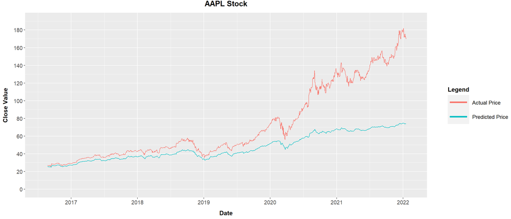

```r
ggplot(aapl[(9001+n_inputs):(9000+n_inputs+dim(pred_test_1)[1]),], aes(x = Date, y = Close, group = 1)) + geom_line(aes(color = "Actual Price")) +
  geom_line(aes(y = pred_test_1, color = "Predicted Price")) +
  labs(x = "Date", y = "Close Value", colour = "Legend") +
  ggtitle("AAPL Stock") +
                        theme(
                        plot.title = element_text(size = 15, face = "bold", hjust = 0.5, vjust = 2.5),
                        axis.title.x = element_text(size = 12, face = "bold", margin = margin(t = 10)),
                        axis.title.y = element_text(size = 12, face = "bold", margin = margin(r = 10)),
                        axis.text.x = element_text(size = 11),
                        axis.text.y = element_text(size = 11),
                        legend.title = element_text(size = 12, face = "bold"),
                        legend.text = element_text(size = 10.5),
                        legend.key.height = unit(1, 'cm'),
                        legend.key.width = unit(1.5, 'cm'),
                        legend.position = "right", legend.margin=margin(l = 30)) +
                        guides(color = guide_legend(override.aes = list(size = 1.5))) +
  scale_x_date(date_breaks = "1 year", date_labels = "%Y", limits = c(as.Date("08/01/16", "%m/%d/%y"),as.Date("02/01/22", "%m/%d/%y"))) +
  scale_y_continuous(breaks = scales::pretty_breaks(n = 10), limits = c(0.00, 190))
```

```r
R2(pred_test_1, aapl$Close[9004:10363])
```

```
##           [,1]
## [1,] 0.9578958
```

## Using Low as well as Close Price

### Normalize the Data

Better performance for LSTM

```r
rec_obj_2 <- recipe(Close ~ Close + Date + Low, aapl) %>%
    step_sqrt(Close) %>%
    step_center(Close) %>%
    step_scale(Close) %>%
    step_sqrt(Low) %>%
    step_center(Low) %>%
    step_scale(Low) %>%
    prep()

aapl_normalized_2 <- bake(rec_obj_2, aapl)

#keep centers for denormalization later
center_history_2 <- rec_obj_2$steps[[2]]$means["Close"]
scale_history_2  <- rec_obj_2$steps[[3]]$sds["Close"]

center_history_22 <- rec_obj_2$steps[[5]]$means["Low"]
scale_history_22  <- rec_obj_2$steps[[6]]$sds["Low"]

c("center" = center_history_2, "scale" = scale_history_2
  ,"center" = center_history_22, "scale" = scale_history_22
  )
```

```
## center.Close  scale.Close   center.Low    scale.Low
##     2.331835     2.826167     2.317514     2.811424
```

```r
aapl_trn_2 <- aapl_normalized_2[1:8000,] #training
aapl_val_2 <- aapl_normalized_2[8001:9000,] #validation
aapl_test_2 <- aapl_normalized_2[9001:10372,] #test for deletion
```

### Reshaping the Data

```r
n_inputs <- 3 #number of inputs in the RNN e.g. 1st it. use first 10 days to predict the 11th
n_predictions <- 1
batch_size <- 10 #number of batches that you give. large the model is faster -- parmeter
```

### Functions

```r
build_windowed_matrix <- function(data, timesteps) { #tranforms data into the  windows of 4+1) if you have 14K rows this produce a matric of 14K x 5
  t(sapply(1:(length(data) - timesteps + 1), function(x)
    data[x:(x + timesteps - 1)]))
}

reshape_3D <- function(df){ #to do it 14kx5x1 since this is required by keras. If it was multivariate (n) it should be  14kx5xn!!!
  dim(df) <- c(dim(df)[1], dim(df)[2], 1)
  df
}

get_x <- function(mtx, n_inputs, batch_size){#for each row gets the the x's (4 in number)
  mtx <- mtx[, 1:n_inputs]
  mtx <- mtx[1:(nrow(mtx) %/% batch_size * batch_size), ]
  reshape_3D(mtx)
}

get_y <- function(mtx, n_inputs, n_predictions, batch_size) {#for each row gets the the y (5th element) + put them in 3D
  mtx <- mtx[, (n_inputs+1):(n_inputs+n_predictions), drop=FALSE]
  mtx <- mtx[1:(nrow(mtx) %/% batch_size * batch_size), , drop=FALSE]
  if(n_predictions==1){
    dim(mtx) <- c(length(mtx)[1], 1)
  }
  reshape_3D(mtx)
}
```

### Extract ‘Close’ Values

Extract close values and disregard dates

```r
trn_2 <- aapl_trn_2 %>% select(Close) %>% pull() #into  vector
val_2 <- aapl_val_2 %>% select(Close) %>% pull()
test_2 <- aapl_test_2 %>% select(Close) %>% pull()

trn_22 <- aapl_trn_2 %>% select(Low) %>% pull() #into  vector
val_22 <- aapl_val_2 %>% select(Low) %>% pull()
test_22 <- aapl_test_2 %>% select(Low) %>% pull()
```

### Build matrices

actually using the functions that I defined above

```r
trn_mtx_2 <- build_windowed_matrix(trn_2, n_inputs+n_predictions)
val_mtx_2 <- build_windowed_matrix(val_2, n_inputs+n_predictions)
test_mtx_2 <- build_windowed_matrix(test_2, n_inputs+n_predictions)

trn_mtx_22 <- build_windowed_matrix(trn_22, n_inputs+n_predictions)
val_mtx_22 <- build_windowed_matrix(val_22, n_inputs+n_predictions)
test_mtx_22 <- build_windowed_matrix(test_22, n_inputs+n_predictions)

trn_mtx_222 <- cbind(trn_mtx_2, trn_mtx_22)
val_mtx_222 <- cbind(val_mtx_2, val_mtx_22)
test_mtx_222 <- cbind(test_mtx_2, test_mtx_22)

X_train_2 <- get_x(trn_mtx_222, n_inputs, batch_size)
Y_train_2 <- get_y(trn_mtx_222, n_inputs, n_predictions, batch_size)
X_val_2 <- get_x(val_mtx_222, n_inputs, batch_size)
Y_val_2 <- get_y(val_mtx_222, n_inputs, n_predictions, batch_size)
X_test_2 <- get_x(test_mtx_222, n_inputs, batch_size)
Y_test_2 <- get_y(test_mtx_222, n_inputs, n_predictions, batch_size)
```

### Build model

```r
model_2 <- keras_model_sequential()

model_2 %>%
  layer_lstm(  #lstm with 32 units in each cell
    units = 32,
    batch_input_shape = c(batch_size, n_inputs, 1)
  )

model_2 %>%
  layer_dense(units = 1)

model_2 %>%
  compile(
    loss = 'mean_squared_error',
    optimizer = 'sgd',
    metrics = list("mean_squared_error")
  )
```

```r
callbacks <- list(#stop criterion depends on if the network is not learning any more...stop the model from training after 5 epochs if there is no learning
  callback_early_stopping(patience = 5)
)
```

```r
history_2 <- model_2 %>% fit(
  x = X_train_2,
  y = Y_train_2,
  validation_data = list(X_val_2, Y_val_2),
  batch_size = batch_size,
  epochs = 100,
  callbacks = callbacks
  ,verbose = 0
)
```

### Predictions

```r
pred_test_2 <- model_2 %>%
  predict(X_test_2, batch_size = batch_size)
# de-normalize to original scale
pred_test_2 <- (pred_test_2 * scale_history_2 + center_history_2)^2 #denormalization
```

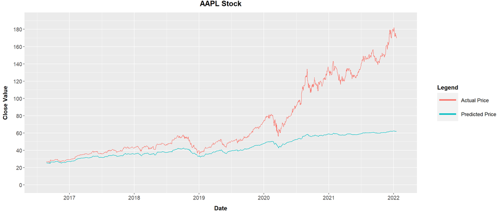

```r
ggplot(aapl[(9001+n_inputs):(9000+n_inputs+dim(pred_test_2)[1]),], aes(x = Date, y = Close, group = 1)) + geom_line(aes(color = "Actual Price")) +
  geom_line(aes(y = pred_test_2, color = "Predicted Price")) +
  labs(x = "Date", y = "Close Value", colour = "Legend") +
  ggtitle("AAPL Stock") +
                        theme(
                        plot.title = element_text(size = 15, face = "bold", hjust = 0.5, vjust = 2.5),
                        axis.title.x = element_text(size = 12, face = "bold", margin = margin(t = 10)),
                        axis.title.y = element_text(size = 12, face = "bold", margin = margin(r = 10)),
                        axis.text.x = element_text(size = 11),
                        axis.text.y = element_text(size = 11),
                        legend.title = element_text(size = 12, face = "bold"),
                        legend.text = element_text(size = 10.5),
                        legend.key.height = unit(1, 'cm'),
                        legend.key.width = unit(1.5, 'cm'),
                        legend.position = "right", legend.margin=margin(l = 30)) +
                        guides(color = guide_legend(override.aes = list(size = 1.5))) +
  scale_x_date(date_breaks = "1 year", date_labels = "%Y", limits = c(as.Date("08/01/16", "%m/%d/%y"),as.Date("02/01/22", "%m/%d/%y"))) +
  scale_y_continuous(breaks = scales::pretty_breaks(n = 10), limits = c(0.00, 190))
```

```r
R2(pred_test_2, aapl$Close[9004:10363])
```

```
##           [,1]
## [1,] 0.9266405
```

## Using Volume as well as Close Price

### Normalize the Data

Better performance for LSTM

```r
rec_obj_3 <- recipe(Close ~ Close + Date + Volume, aapl) %>%
    step_log(Close, base = exp(1)) %>%
    step_center(Close) %>%
    step_scale(Close) %>%
    step_log(Volume, base = exp(1)) %>%
    step_center(Volume) %>%
    step_scale(Volume) %>%
    prep()

aapl_normalized_3 <- bake(rec_obj_3, aapl)

#keep centers for denormalization later
center_history_3 <- rec_obj_3$steps[[2]]$means["Close"]
scale_history_3  <- rec_obj_3$steps[[3]]$sds["Close"]

center_history_33 <- rec_obj_3$steps[[5]]$means["Volume"]
scale_history_33  <- rec_obj_3$steps[[6]]$sds["Volume"]

c("center" = center_history_3, "scale" = scale_history_3
  ,"center" = center_history_33, "scale" = scale_history_33
  )
```

```
##  center.Close   scale.Close center.Volume  scale.Volume
##     0.3908791     2.2317268    19.2427217     0.8856951
```

```r
aapl_trn_3 <- aapl_normalized_3[1:8000,] #training
aapl_val_3 <- aapl_normalized_3[8001:9000,] #validation
aapl_test_3 <- aapl_normalized_3[9001:10372,] #test for deletion
```

### Reshaping the Data

```r
n_inputs <- 3 #number of inputs in the RNN e.g. 1st it. use first 10 days to predict the 11th
n_predictions <- 1
batch_size <- 10 #number of batches that you give. large the model is faster -- parmeter
```

### Functions

```r
build_windowed_matrix <- function(data, timesteps) { #tranforms data into the  windows of 4+1) if you have 14K rows this produce a matric of 14K x 5
  t(sapply(1:(length(data) - timesteps + 1), function(x)
    data[x:(x + timesteps - 1)]))
}

reshape_3D <- function(df){ #to do it 14kx5x1 since this is required by keras. If it was multivariate (n) it should be  14kx5xn!!!
  dim(df) <- c(dim(df)[1], dim(df)[2], 1)
  df
}

get_x <- function(mtx, n_inputs, batch_size){#for each row gets the the x's (4 in number)
  mtx <- mtx[, 1:n_inputs]
  mtx <- mtx[1:(nrow(mtx) %/% batch_size * batch_size), ]
  reshape_3D(mtx)
}

get_y <- function(mtx, n_inputs, n_predictions, batch_size) {#for each row gets the the y (5th element) + put them in 3D
  mtx <- mtx[, (n_inputs+1):(n_inputs+n_predictions), drop=FALSE]
  mtx <- mtx[1:(nrow(mtx) %/% batch_size * batch_size), , drop=FALSE]
  if(n_predictions==1){
    dim(mtx) <- c(length(mtx)[1], 1)
  }
  reshape_3D(mtx)
}
```

### Extract ‘Close’ Values

Extract close values and disregard dates

```r
trn_3 <- aapl_trn_3 %>% select(Close) %>% pull() #into  vector
val_3 <- aapl_val_3 %>% select(Close) %>% pull()
test_3 <- aapl_test_3 %>% select(Close) %>% pull()

trn_33 <- aapl_trn_3 %>% select(Volume) %>% pull() #into  vector
val_33 <- aapl_val_3 %>% select(Volume) %>% pull()
test_33 <- aapl_test_3 %>% select(Volume) %>% pull()
```

### Build matrices

actually using the functions that I defined above

```r
trn_mtx_3 <- build_windowed_matrix(trn_3, n_inputs+n_predictions)
val_mtx_3 <- build_windowed_matrix(val_3, n_inputs+n_predictions)
test_mtx_3 <- build_windowed_matrix(test_3, n_inputs+n_predictions)

trn_mtx_33 <- build_windowed_matrix(trn_33, n_inputs+n_predictions)
val_mtx_33 <- build_windowed_matrix(val_33, n_inputs+n_predictions)
test_mtx_33 <- build_windowed_matrix(test_33, n_inputs+n_predictions)

trn_mtx_333 <- cbind(trn_mtx_3, trn_mtx_33)
val_mtx_333 <- cbind(val_mtx_3, val_mtx_33)
test_mtx_333 <- cbind(test_mtx_3, test_mtx_33)

X_train_3 <- get_x(trn_mtx_333, n_inputs, batch_size)
Y_train_3 <- get_y(trn_mtx_333, n_inputs, n_predictions, batch_size)
X_val_3 <- get_x(val_mtx_333, n_inputs, batch_size)
Y_val_3 <- get_y(val_mtx_333, n_inputs, n_predictions, batch_size)
X_test_3 <- get_x(test_mtx_333, n_inputs, batch_size)
Y_test_3 <- get_y(test_mtx_333, n_inputs, n_predictions, batch_size)
```

### Build model

```r
model_3 <- keras_model_sequential()

model_3 %>%
  layer_lstm(  #lstm with 32 units in each cell
    units = 32,
    batch_input_shape = c(batch_size, n_inputs, 1)
  )

model_3 %>%
  layer_dense(units = 1)

model_3 %>%
  compile(
    loss = 'mean_squared_error',
    optimizer = 'sgd',
    metrics = list("mean_squared_error")
  )
```

```r
callbacks <- list(#stop criterion depends on if the network is not learning any more...stop the model from training after 5 epochs if there is no learning
  callback_early_stopping(patience = 5)
)
```

```r
history_3 <- model_3 %>% fit(
  x = X_train_3,
  y = Y_train_3,
  validation_data = list(X_val_3, Y_val_3),
  batch_size = batch_size,
  epochs = 100,
  callbacks = callbacks
  ,verbose = 0
)
```

### Predictions

```r
pred_test_3 <- model_3 %>%
  predict(X_test_3, batch_size = batch_size)
# de-normalize to original scale
pred_test_3 <- exp((pred_test_3 * scale_history_3 + center_history_3)) #denormalization
```

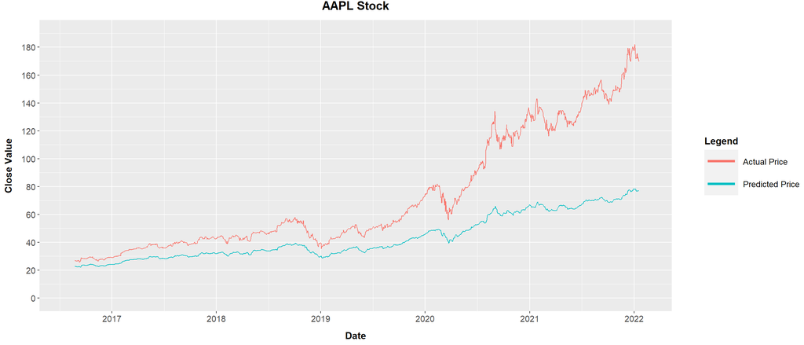

```r
ggplot(aapl[(9001+n_inputs):(9000+n_inputs+dim(pred_test_3)[1]),], aes(x = Date, y = Close, group = 1)) + geom_line(aes(color = "Actual Price")) +
  geom_line(aes(y = pred_test_3, color = "Predicted Price")) +
  labs(x = "Date", y = "Close Value", colour = "Legend") +
  ggtitle("AAPL Stock") +
                        theme(
                        plot.title = element_text(size = 15, face = "bold", hjust = 0.5, vjust = 2.5),
                        axis.title.x = element_text(size = 12, face = "bold", margin = margin(t = 10)),
                        axis.title.y = element_text(size = 12, face = "bold", margin = margin(r = 10)),
                        axis.text.x = element_text(size = 11),
                        axis.text.y = element_text(size = 11),
                        legend.title = element_text(size = 12, face = "bold"),
                        legend.text = element_text(size = 10.5),
                        legend.key.height = unit(1, 'cm'),
                        legend.key.width = unit(1.5, 'cm'),
                        legend.position = "right", legend.margin=margin(l = 30)) +
                        guides(color = guide_legend(override.aes = list(size = 1.5))) +
  scale_x_date(date_breaks = "1 year", date_labels = "%Y", limits = c(as.Date("08/01/16", "%m/%d/%y"),as.Date("02/01/22", "%m/%d/%y"))) +
  scale_y_continuous(breaks = scales::pretty_breaks(n = 10), limits = c(0.00, 190))
```

```r
R2(pred_test_3, aapl$Close[9004:10363])
```

```
##           [,1]
## [1,] 0.9868369
```

## Using Adj Close as well as Close Price

### Normalize the Data

Better performance for LSTM

```r
names(aapl)[names(aapl) == "Adj Close"] <- "Adj_Close"

rec_obj_4 <- recipe(Close ~ Close + Date + Adj_Close, aapl) %>%
    step_sqrt(Close) %>%
    step_center(Close) %>%
    step_scale(Close) %>%
    step_sqrt(Adj_Close) %>%
    step_center(Adj_Close) %>%
    step_scale(Adj_Close) %>%
    prep()

aapl_normalized_4 <- bake(rec_obj_4, aapl)

#keep centers for denormalization later
center_history_4 <- rec_obj_4$steps[[2]]$means["Close"]
scale_history_4  <- rec_obj_4$steps[[3]]$sds["Close"]

center_history_44 <- rec_obj_4$steps[[5]]$means["Adj_Close"]
scale_history_44  <- rec_obj_4$steps[[6]]$sds["Adj_Close"]

c("center" = center_history_4, "scale" = scale_history_4
  ,"center" = center_history_44, "scale" = scale_history_44
  )
```

```
##     center.Close      scale.Close center.Adj_Close  scale.Adj_Close
##         2.331835         2.826167         2.233259         2.799102
```

```r
aapl_trn_4 <- aapl_normalized_4[1:8000,] #training
aapl_val_4 <- aapl_normalized_4[8001:9000,] #validation
aapl_test_4 <- aapl_normalized_4[9001:10372,] #test for deletion
```

### Reshaping the Data

```r
n_inputs <- 3 #number of inputs in the RNN e.g. 1st it. use first 10 days to predict the 11th
n_predictions <- 1
batch_size <- 10 #number of batches that you give. large the model is faster -- parmeter
```

### Functions

```r
build_windowed_matrix <- function(data, timesteps) { #tranforms data into the  windows of 4+1) if you have 14K rows this produce a matric of 14K x 5
  t(sapply(1:(length(data) - timesteps + 1), function(x)
    data[x:(x + timesteps - 1)]))
}

reshape_3D <- function(df){ #to do it 14kx5x1 since this is required by keras. If it was multivariate (n) it should be  14kx5xn!!!
  dim(df) <- c(dim(df)[1], dim(df)[2], 1)
  df
}

get_x <- function(mtx, n_inputs, batch_size){#for each row gets the the x's (4 in number)
  mtx <- mtx[, 1:n_inputs]
  mtx <- mtx[1:(nrow(mtx) %/% batch_size * batch_size), ]
  reshape_3D(mtx)
}

get_y <- function(mtx, n_inputs, n_predictions, batch_size) {#for each row gets the the y (5th element) + put them in 3D
  mtx <- mtx[, (n_inputs+1):(n_inputs+n_predictions), drop=FALSE]
  mtx <- mtx[1:(nrow(mtx) %/% batch_size * batch_size), , drop=FALSE]
  if(n_predictions==1){
    dim(mtx) <- c(length(mtx)[1], 1)
  }
  reshape_3D(mtx)
}
```

### Extract ‘Close’ Values

Extract close values and disregard dates

```r
trn_4 <- aapl_trn_4 %>% select(Close) %>% pull() #into  vector
val_4 <- aapl_val_4 %>% select(Close) %>% pull()
test_4 <- aapl_test_4 %>% select(Close) %>% pull()

trn_44 <- aapl_trn_4 %>% select(Adj_Close) %>% pull() #into  vector
val_44 <- aapl_val_4 %>% select(Adj_Close) %>% pull()
test_44 <- aapl_test_4 %>% select(Adj_Close) %>% pull()
```

### Build matrices

actually using the functions that I defined above

```r
trn_mtx_4 <- build_windowed_matrix(trn_4, n_inputs+n_predictions)
val_mtx_4 <- build_windowed_matrix(val_4, n_inputs+n_predictions)
test_mtx_4 <- build_windowed_matrix(test_4, n_inputs+n_predictions)

trn_mtx_44 <- build_windowed_matrix(trn_44, n_inputs+n_predictions)
val_mtx_44 <- build_windowed_matrix(val_44, n_inputs+n_predictions)
test_mtx_44 <- build_windowed_matrix(test_44, n_inputs+n_predictions)

trn_mtx_444 <- cbind(trn_mtx_4, trn_mtx_44)
val_mtx_444 <- cbind(val_mtx_4, val_mtx_44)
test_mtx_444 <- cbind(test_mtx_4, test_mtx_44)

X_train_4 <- get_x(trn_mtx_444, n_inputs, batch_size)
Y_train_4 <- get_y(trn_mtx_444, n_inputs, n_predictions, batch_size)
X_val_4 <- get_x(val_mtx_444, n_inputs, batch_size)
Y_val_4 <- get_y(val_mtx_444, n_inputs, n_predictions, batch_size)
X_test_4 <- get_x(test_mtx_444, n_inputs, batch_size)
Y_test_4 <- get_y(test_mtx_444, n_inputs, n_predictions, batch_size)
```

### Build model

```r
model_4 <- keras_model_sequential()

model_4 %>%
  layer_lstm(  #lstm with 32 units in each cell
    units = 32,
    batch_input_shape = c(batch_size, n_inputs, 1)
  )

model_4 %>%
  layer_dense(units = 1)

model_4 %>%
  compile(
    loss = 'mean_squared_error',
    optimizer = 'sgd',
    metrics = list("mean_squared_error")
  )
```

```r
callbacks <- list(#stop criterion depends on if the network is not learning any more...stop the model from training after 5 epochs if there is no learning
  callback_early_stopping(patience = 5)
)
```

```r
history_4 <- model_4 %>% fit(
  x = X_train_4,
  y = Y_train_4,
  validation_data = list(X_val_4, Y_val_4),
  batch_size = batch_size,
  epochs = 100,
  callbacks = callbacks
  ,verbose = 0
)
```

### Predictions

```r
pred_test_4 <- model_4 %>%
  predict(X_test_4, batch_size = batch_size)
# de-normalize to original scale
pred_test_4 <- (pred_test_4 * scale_history_4 + center_history_4)^2 #denormalization
```

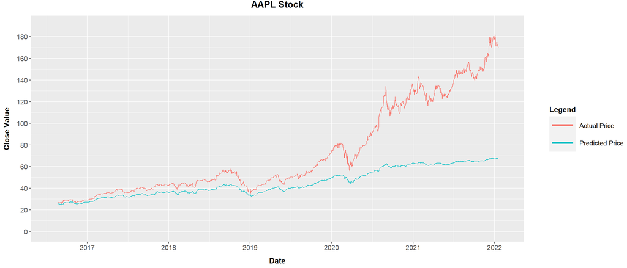

```r
ggplot(aapl[(9001+n_inputs):(9000+n_inputs+dim(pred_test_4)[1]),], aes(x = Date, y = Close, group = 1)) + geom_line(aes(color = "Actual Price")) +
  geom_line(aes(y = pred_test_4, color = "Predicted Price")) +
  labs(x = "Date", y = "Close Value", colour = "Legend") +
  ggtitle("AAPL Stock") +
                        theme(
                        plot.title = element_text(size = 15, face = "bold", hjust = 0.5, vjust = 2.5),
                        axis.title.x = element_text(size = 12, face = "bold", margin = margin(t = 10)),
                        axis.title.y = element_text(size = 12, face = "bold", margin = margin(r = 10)),
                        axis.text.x = element_text(size = 11),
                        axis.text.y = element_text(size = 11),
                        legend.title = element_text(size = 12, face = "bold"),
                        legend.text = element_text(size = 10.5),
                        legend.key.height = unit(1, 'cm'),
                        legend.key.width = unit(1.5, 'cm'),
                        legend.position = "right", legend.margin=margin(l = 30)) +
                        guides(color = guide_legend(override.aes = list(size = 1.5))) +
  scale_x_date(date_breaks = "1 year", date_labels = "%Y", limits = c(as.Date("08/01/16", "%m/%d/%y"),as.Date("02/01/22", "%m/%d/%y"))) +
  scale_y_continuous(breaks = scales::pretty_breaks(n = 10), limits = c(0.00, 190))
```

```r
R2(pred_test_4, aapl$Close[9004:10363])
```

```
##           [,1]
## [1,] 0.9438863
```

## Using Adj Close, High, Low, Volume, and Open as well as Close Price

### Normalize the Data

Better performance for LSTM

```r
rec_obj_5 <- recipe(Close ~ Close + Date + Adj_Close + High + Low + Volume + Open, aapl) %>%
    step_log(Close, base = exp(1)) %>%
    step_center(Close) %>%
    step_scale(Close) %>%
    step_log(Adj_Close, base = exp(1)) %>%
    step_center(Adj_Close) %>%
    step_scale(Adj_Close) %>%
    step_log(High, base = exp(1)) %>%
    step_center(High) %>%
    step_scale(High) %>%
    step_log(Low, base = exp(1)) %>%
    step_center(Low) %>%
    step_scale(Low) %>%
    step_log(Volume, base = exp(1)) %>%
    step_center(Volume) %>%
    step_scale(Volume) %>%
    step_log(Open, base = exp(1)) %>%
    step_center(Open) %>%
    step_scale(Open) %>%
    prep()

aapl_normalized_5 <- bake(rec_obj_5, aapl)

#keep centers for denormalization later
center_history_5 <- rec_obj_5$steps[[2]]$means["Close"]
scale_history_5  <- rec_obj_5$steps[[3]]$sds["Close"]

center_history_55 <- rec_obj_5$steps[[5]]$means["Adj_Close"]
scale_history_55  <- rec_obj_5$steps[[6]]$sds["Adj_Close"]

center_history_555 <- rec_obj_5$steps[[8]]$means["High"]
scale_history_555  <- rec_obj_5$steps[[9]]$sds["High"]

center_history_5555 <- rec_obj_5$steps[[11]]$means["Low"]
scale_history_5555  <- rec_obj_5$steps[[12]]$sds["Low"]

center_history_55555 <- rec_obj_5$steps[[14]]$means["Volume"]
scale_history_55555  <- rec_obj_5$steps[[15]]$sds["Volume"]

center_history_555555 <- rec_obj_5$steps[[17]]$means["Open"]
scale_history_555555  <- rec_obj_5$steps[[18]]$sds["Open"]

c("center" = center_history_5, "scale" = scale_history_5
  ,"center" = center_history_55, "scale" = scale_history_55
  ,"center" = center_history_555, "scale" = scale_history_555
  ,"center" = center_history_5555, "scale" = scale_history_5555
  ,"center" = center_history_55555, "scale" = scale_history_55555
  ,"center" = center_history_555555, "scale" = scale_history_555555
  )
```

```
##     center.Close      scale.Close center.Adj_Close  scale.Adj_Close
##        0.3908791        2.2317268        0.2336857        2.2887761
##      center.High       scale.High       center.Low        scale.Low
##        0.4066936        2.2280175        0.3751652        2.2342953
##    center.Volume     scale.Volume      center.Open       scale.Open
##       19.2427217        0.8856951        0.3912360        2.2311671
```

```r
aapl_trn_5 <- aapl_normalized_5[1:8000,] #training
aapl_val_5 <- aapl_normalized_5[8001:9000,] #validation
aapl_test_5 <- aapl_normalized_5[9001:10372,] #test for deletion
```

### Reshaping the Data

```r
n_inputs <- 3 #number of inputs in the RNN e.g. 1st it. use first 10 days to predict the 11th
n_predictions <- 1
batch_size <- 10 #number of batches that you give. large the model is faster -- parmeter
```

### Functions

```r
build_windowed_matrix <- function(data, timesteps) { #tranforms data into the  windows of 4+1) if you have 14K rows this produce a matric of 14K x 5
  t(sapply(1:(length(data) - timesteps + 1), function(x)
    data[x:(x + timesteps - 1)]))
}

reshape_3D <- function(df){ #to do it 14kx5x1 since this is required by keras. If it was multivariate (n) it should be  14kx5xn!!!
  dim(df) <- c(dim(df)[1], dim(df)[2], 1)
  df
}

get_x <- function(mtx, n_inputs, batch_size){#for each row gets the the x's (4 in number)
  mtx <- mtx[, 1:n_inputs]
  mtx <- mtx[1:(nrow(mtx) %/% batch_size * batch_size), ]
  reshape_3D(mtx)
}

get_y <- function(mtx, n_inputs, n_predictions, batch_size) {#for each row gets the the y (5th element) + put them in 3D
  mtx <- mtx[, (n_inputs+1):(n_inputs+n_predictions), drop=FALSE]
  mtx <- mtx[1:(nrow(mtx) %/% batch_size * batch_size), , drop=FALSE]
  if(n_predictions==1){
    dim(mtx) <- c(length(mtx)[1], 1)
  }
  reshape_3D(mtx)
}
```

### Extract ‘Close’ Values

Extract close values and disregard dates

```r
trn_5 <- aapl_trn_5 %>% select(Close) %>% pull() #into  vector
val_5 <- aapl_val_5 %>% select(Close) %>% pull()
test_5 <- aapl_test_5 %>% select(Close) %>% pull()

trn_55 <- aapl_trn_5 %>% select(Adj_Close) %>% pull() #into  vector
val_55 <- aapl_val_5 %>% select(Adj_Close) %>% pull()
test_55 <- aapl_test_5 %>% select(Adj_Close) %>% pull()

trn_555 <- aapl_trn_5 %>% select(High) %>% pull() #into  vector
val_555 <- aapl_val_5 %>% select(High) %>% pull()
test_555 <- aapl_test_5 %>% select(High) %>% pull()

trn_5555 <- aapl_trn_5 %>% select(Low) %>% pull() #into  vector
val_5555 <- aapl_val_5 %>% select(Low) %>% pull()
test_5555 <- aapl_test_5 %>% select(Low) %>% pull()

trn_55555 <- aapl_trn_5 %>% select(Volume) %>% pull() #into  vector
val_55555 <- aapl_val_5 %>% select(Volume) %>% pull()
test_55555 <- aapl_test_5 %>% select(Volume) %>% pull()

trn_555555 <- aapl_trn_5 %>% select(Open) %>% pull() #into  vector
val_555555 <- aapl_val_5 %>% select(Open) %>% pull()
test_555555 <- aapl_test_5 %>% select(Open) %>% pull()
```

### Build matrices

actually using the functions that I defined above

```r
trn_mtx_5 <- build_windowed_matrix(trn_5, n_inputs+n_predictions)
val_mtx_5 <- build_windowed_matrix(val_5, n_inputs+n_predictions)
test_mtx_5 <- build_windowed_matrix(test_5, n_inputs+n_predictions)

trn_mtx_55 <- build_windowed_matrix(trn_55, n_inputs+n_predictions)
val_mtx_55 <- build_windowed_matrix(val_55, n_inputs+n_predictions)
test_mtx_55 <- build_windowed_matrix(test_55, n_inputs+n_predictions)

trn_mtx_555 <- build_windowed_matrix(trn_555, n_inputs+n_predictions)
val_mtx_555 <- build_windowed_matrix(val_555, n_inputs+n_predictions)
test_mtx_555 <- build_windowed_matrix(test_555, n_inputs+n_predictions)

trn_mtx_5555 <- build_windowed_matrix(trn_5555, n_inputs+n_predictions)
val_mtx_5555 <- build_windowed_matrix(val_5555, n_inputs+n_predictions)
test_mtx_5555 <- build_windowed_matrix(test_5555, n_inputs+n_predictions)

trn_mtx_55555 <- build_windowed_matrix(trn_55555, n_inputs+n_predictions)
val_mtx_55555 <- build_windowed_matrix(val_55555, n_inputs+n_predictions)
test_mtx_55555 <- build_windowed_matrix(test_55555, n_inputs+n_predictions)

trn_mtx_555555 <- build_windowed_matrix(trn_555555, n_inputs+n_predictions)
val_mtx_555555 <- build_windowed_matrix(val_555555, n_inputs+n_predictions)
test_mtx_555555 <- build_windowed_matrix(test_555555, n_inputs+n_predictions)

trn_mtx_5555555 <- cbind(trn_mtx_5, trn_mtx_55, trn_mtx_555, trn_mtx_5555, trn_mtx_55555, trn_mtx_555555)
val_mtx_5555555 <- cbind(val_mtx_5, val_mtx_55, val_mtx_555, val_mtx_5555, val_mtx_55555, val_mtx_555555)
test_mtx_5555555 <- cbind(test_mtx_5, test_mtx_55, test_mtx_555, test_mtx_5555, test_mtx_55555, test_mtx_555555)

X_train_5 <- get_x(trn_mtx_5555555, n_inputs, batch_size)
Y_train_5 <- get_y(trn_mtx_5555555, n_inputs, n_predictions, batch_size)
X_val_5 <- get_x(val_mtx_5555555, n_inputs, batch_size)
Y_val_5 <- get_y(val_mtx_5555555, n_inputs, n_predictions, batch_size)
X_test_5 <- get_x(test_mtx_5555555, n_inputs, batch_size)
Y_test_5 <- get_y(test_mtx_5555555, n_inputs, n_predictions, batch_size)
```

### Build model

```r
model_5 <- keras_model_sequential()

model_5 %>%
  layer_lstm(  #lstm with 32 units in each cell
    units = 32,
    batch_input_shape = c(batch_size, n_inputs, 1)
  )

model_5 %>%
  layer_dense(units = 1)

model_5 %>%
  compile(
    loss = 'mean_squared_error',
    optimizer = 'sgd',
    metrics = list("mean_squared_error")
  )
```

```r
callbacks <- list(#stop criterion depends on if the network is not learning any more...stop the model from training after 5 epochs if there is no learning
  callback_early_stopping(patience = 5)
)
```

```r
history_5 <- model_5 %>% fit(
  x = X_train_5,
  y = Y_train_5,
  validation_data = list(X_val_5, Y_val_5),
  batch_size = batch_size,
  epochs = 100
  ,callbacks = callbacks
  ,verbose = 0
)
```

### Predictions

```r
pred_test_5 <- model_5 %>%
  predict(X_test_5, batch_size = batch_size)
# de-normalize to original scale
pred_test_5 <- exp((pred_test_5 * scale_history_5 + center_history_5))  #denormalization
```

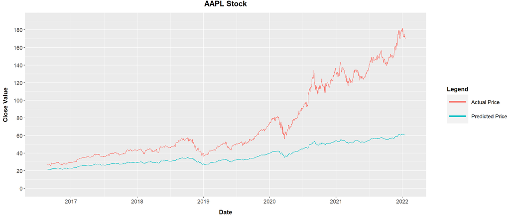

```r
ggplot(aapl[(9001+n_inputs):(9000+n_inputs+dim(pred_test_5)[1]),], aes(x = Date, y = Close, group = 1)) + geom_line(aes(color = "Actual Price")) +
  geom_line(aes(y = pred_test_5, color = "Predicted Price")) +
  labs(x = "Date", y = "Close Value", colour = "Legend") +
  ggtitle("AAPL Stock") +
                        theme(
                        plot.title = element_text(size = 15, face = "bold", hjust = 0.5, vjust = 2.5),
                        axis.title.x = element_text(size = 12, face = "bold", margin = margin(t = 10)),
                        axis.title.y = element_text(size = 12, face = "bold", margin = margin(r = 10)),
                        axis.text.x = element_text(size = 11),
                        axis.text.y = element_text(size = 11),
                        legend.title = element_text(size = 12, face = "bold"),
                        legend.text = element_text(size = 10.5),
                        legend.key.height = unit(1, 'cm'),
                        legend.key.width = unit(1.5, 'cm'),
                        legend.position = "right", legend.margin=margin(l = 30)) +
                        guides(color = guide_legend(override.aes = list(size = 1.5))) +
  scale_x_date(date_breaks = "1 year", date_labels = "%Y", limits = c(as.Date("08/01/16", "%m/%d/%y"),as.Date("02/01/22", "%m/%d/%y"))) +
  scale_y_continuous(breaks = scales::pretty_breaks(n = 10), limits = c(0.00, 190))
```

```r
R2(pred_test_5, aapl$Close[9004:10363])
```

```
##           [,1]
## [1,] 0.9783324
```

```r
comparisons_R2 <- as.data.frame(c(R2(pred_test, aapl$Close[9004:10363]), R2(pred_test_1, aapl$Close[9004:10363]), R2(pred_test_2, aapl$Close[9004:10363]), R2(pred_test_3, aapl$Close[9004:10363]), R2(pred_test_4, aapl$Close[9004:10363]), R2(pred_test_5, aapl$Close[9004:10363])))

comparisons_RMSE <- as.data.frame(c(RMSE(pred_test, aapl$Close[9004:10363]), RMSE(pred_test_1, aapl$Close[9004:10363]), RMSE(pred_test_2, aapl$Close[9004:10363]), RMSE(pred_test_3, aapl$Close[9004:10363]), RMSE(pred_test_4, aapl$Close[9004:10363]), RMSE(pred_test_5, aapl$Close[9004:10363])))

comparisons <- cbind(comparisons_R2, comparisons_RMSE)

comparisons$Model = c("Close Price Only", "Close Price & High", "Close Price & Low", "Close Price & Volume", "Close Price & Adj Close Price", "Close Price, High, Low, Volume, Adj Close Price, Open Price")
names(comparisons)[names(comparisons) == "c(R2(pred_test, aapl$Close[9004:10363]), R2(pred_test_1, aapl$Close[9004:10363]), R2(pred_test_2, aapl$Close[9004:10363]), R2(pred_test_3, aapl$Close[9004:10363]), R2(pred_test_4, aapl$Close[9004:10363]), R2(pred_test_5, aapl$Close[9004:10363]))"] <- "R_Squared"
names(comparisons)[names(comparisons) == "c(RMSE(pred_test, aapl$Close[9004:10363]), RMSE(pred_test_1, aapl$Close[9004:10363]), RMSE(pred_test_2, aapl$Close[9004:10363]), RMSE(pred_test_3, aapl$Close[9004:10363]), RMSE(pred_test_4, aapl$Close[9004:10363]), RMSE(pred_test_5, aapl$Close[9004:10363]))"] <- "RMSE"

comparisons <- comparisons[, c(3,1,2)]
comparisons <- comparisons[order(comparisons$R_Squared, -comparisons$RMSE),]

comparisons
```

```
##                                                         Model R_Squared
## 3                                           Close Price & Low 0.9266405
## 5                               Close Price & Adj Close Price 0.9438863
## 1                                            Close Price Only 0.9574976
## 2                                          Close Price & High 0.9578958
## 6 Close Price, High, Low, Volume, Adj Close Price, Open Price 0.9783324
## 4                                        Close Price & Volume 0.9868369
##       RMSE
## 3 42.66085
## 5 40.26519
## 1 39.02544
## 2 37.54735
## 6 46.44875
## 4 39.16758
```

# Part 2 (b)

## Base Model

### Normalize the Data

Better performance for LSTM

```r
rec_obj_6 <- recipe(Close ~ Close + Date, aapl) %>%
    step_sqrt(Close) %>%
    step_center(Close) %>%
    step_scale(Close) %>%
    prep()

aapl_normalized_6 <- bake(rec_obj_6, aapl)

#keep centers for denormalization later
center_history_6 <- rec_obj_6$steps[[2]]$means["Close"]
scale_history_6  <- rec_obj_6$steps[[3]]$sds["Close"]

c("center" = center_history_6, "scale" = scale_history_6)
```

```
## center.Close  scale.Close
##     2.331835     2.826167
```

```r
aapl_trn_6 <- aapl_normalized_6[1:8000,] #training
aapl_val_6 <- aapl_normalized_6[8001:9000,] #validation
aapl_test_6 <- aapl_normalized_6[9001:10372,] #test for deletion
```

### Reshaping the Data

```r
n_inputs <- 3 #number of inputs in the RNN e.g. 1st it. use first 10 days to predict the 11th
n_predictions <- 1
batch_size <- 10 #number of batches that you give. large the model is faster -- parmeter
```

### Functions

```r
build_windowed_matrix <- function(data, timesteps) { #tranforms data into the  windows of 4+1) if you have 14K rows this produce a matric of 14K x 5
  t(sapply(1:(length(data) - timesteps + 1), function(x)
    data[x:(x + timesteps - 1)]))
}

reshape_3D <- function(df){ #to do it 14kx5x1 since this is required by keras. If it was multivariate (n) it should be  14kx5xn!!!
  dim(df) <- c(dim(df)[1], dim(df)[2], 1)
  df
}

get_x <- function(mtx, n_inputs, batch_size){#for each row gets the the x's (4 in number)
  mtx <- mtx[, 1:n_inputs]
  mtx <- mtx[1:(nrow(mtx) %/% batch_size * batch_size), ]
  reshape_3D(mtx)
}

get_y <- function(mtx, n_inputs, n_predictions, batch_size) {#for each row gets the the y (5th element) + put them in 3D
  mtx <- mtx[, (n_inputs+1):(n_inputs+n_predictions), drop=FALSE]
  mtx <- mtx[1:(nrow(mtx) %/% batch_size * batch_size), , drop=FALSE]
  if(n_predictions==1){
    dim(mtx) <- c(length(mtx)[1], 1)
  }
  reshape_3D(mtx)
}
```

### Extract ‘Close’ Values

Extract close values and disregard dates

```r
trn_6 <- aapl_trn_6 %>% select(Close) %>% pull() #into  vector
val_6 <- aapl_val_6 %>% select(Close) %>% pull()
test_6 <- aapl_test_6 %>% select(Close) %>% pull()
```

### Build matrices

actually using the functions that I defined above

```r
trn_mtx_6 <- build_windowed_matrix(trn_6, n_inputs+n_predictions)
val_mtx_6 <- build_windowed_matrix(val_6, n_inputs+n_predictions)
test_mtx_6 <- build_windowed_matrix(test_6, n_inputs+n_predictions)

X_train_6 <- get_x(trn_mtx_6, n_inputs, batch_size)
Y_train_6 <- get_y(trn_mtx_6, n_inputs, n_predictions, batch_size)
X_val_6 <- get_x(val_mtx_6, n_inputs, batch_size)
Y_val_6 <- get_y(val_mtx_6, n_inputs, n_predictions, batch_size)
X_test_6 <- get_x(test_mtx_6, n_inputs, batch_size)
Y_test_6 <- get_y(test_mtx_6, n_inputs, n_predictions, batch_size)
```

### Build model

```r
model_6 <- keras_model_sequential()

model_6 %>%
  layer_simple_rnn(  #rnn with 32 units in each cell
    units = 32,
    batch_input_shape = c(batch_size, n_inputs, 1)
  )

model_6 %>%
  layer_dense(units = 1)

model_6 %>%
  compile(
    loss = 'mean_squared_error',
    optimizer = 'sgd',
    metrics = list("mean_squared_error")
  )
```

```r
callbacks <- list(#stop criterion depends on if the network is not learning any more...stop the model from training after 5 epochs if there is no learning
  callback_early_stopping(patience = 5)
)
```

```r
history_6 <- model_6 %>% fit(
  x = X_train_6,
  y = Y_train_6,
  validation_data = list(X_val_6, Y_val_6),
  batch_size = batch_size,
  epochs = 100,
  callbacks = callbacks
  ,verbose = 0
)
```

### Predictions

```r
pred_test_6 <- model_6 %>%
  predict(X_test_6, batch_size = batch_size)
# de-normalize to original scale
pred_test_6 <- (pred_test_6 * scale_history_6 + center_history_6)^2 #denormalization
```

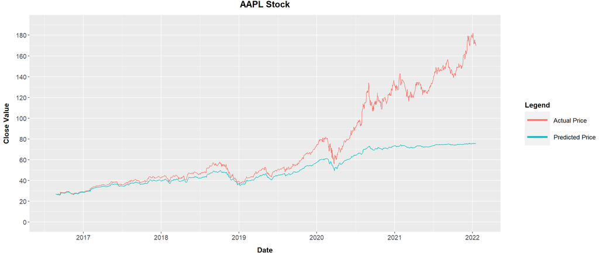

```r
ggplot(aapl[(9001+n_inputs):(9000+n_inputs+dim(pred_test_6)[1]),], aes(x = Date, y = Close, group = 1)) + geom_line(aes(color = "Actual Price")) +
  geom_line(aes(y = pred_test_6, color = "Predicted Price")) +
  labs(x = "Date", y = "Close Value", colour = "Legend") +
  ggtitle("AAPL Stock") +
                        theme(
                        plot.title = element_text(size = 15, face = "bold", hjust = 0.5, vjust = 2.5),
                        axis.title.x = element_text(size = 12, face = "bold", margin = margin(t = 10)),
                        axis.title.y = element_text(size = 12, face = "bold", margin = margin(r = 10)),
                        axis.text.x = element_text(size = 11),
                        axis.text.y = element_text(size = 11),
                        legend.title = element_text(size = 12, face = "bold"),
                        legend.text = element_text(size = 10.5),
                        legend.key.height = unit(1, 'cm'),
                        legend.key.width = unit(1.5, 'cm'),
                        legend.position = "right", legend.margin=margin(l = 30)) +
                        guides(color = guide_legend(override.aes = list(size = 1.5))) +
  scale_x_date(date_breaks = "1 year", date_labels = "%Y", limits = c(as.Date("08/01/16", "%m/%d/%y"),as.Date("02/01/22", "%m/%d/%y"))) +
  scale_y_continuous(breaks = scales::pretty_breaks(n = 10), limits = c(0.00, 190))
```

```r
R2(pred_test_6, aapl$Close[9004:10363])
```

```
##           [,1]
## [1,] 0.9247131
```

## Model 1

### Normalize the Data

Better performance for LSTM

```r
rec_obj_7 <- recipe(Close ~ Close + Date + Adj_Close + Low, aapl) %>%
    step_sqrt(Close) %>%
    step_center(Close) %>%
    step_scale(Close) %>%
    step_sqrt(Adj_Close) %>%
    step_center(Adj_Close) %>%
    step_scale(Adj_Close) %>%
    step_sqrt(Low) %>%
    step_center(Low) %>%
    step_scale(Low) %>%
    prep()

aapl_normalized_7 <- bake(rec_obj_7, aapl)

#keep centers for denormalization later
center_history_7 <- rec_obj_7$steps[[2]]$means["Close"]
scale_history_7  <- rec_obj_7$steps[[3]]$sds["Close"]

center_history_77 <- rec_obj_7$steps[[5]]$means["Adj_Close"]
scale_history_77  <- rec_obj_7$steps[[6]]$sds["Adj_Close"]

center_history_777 <- rec_obj_7$steps[[8]]$means["Low"]
scale_history_777  <- rec_obj_7$steps[[9]]$sds["Low"]

c("center" = center_history_7, "scale" = scale_history_7
  ,"center" = center_history_77, "scale" = scale_history_77
  ,"center" = center_history_777, "scale" = scale_history_777
  )
```

```
##     center.Close      scale.Close center.Adj_Close  scale.Adj_Close
##         2.331835         2.826167         2.233259         2.799102
##       center.Low        scale.Low
##         2.317514         2.811424
```

```r
aapl_trn_7 <- aapl_normalized_7[1:8000,] #training
aapl_val_7 <- aapl_normalized_7[8001:9000,] #validation
aapl_test_7 <- aapl_normalized_7[9001:10372,] #test for deletion
```

### Reshaping the Data

```r
n_inputs <- 3 #number of inputs in the RNN e.g. 1st it. use first 10 days to predict the 11th
n_predictions <- 1
batch_size <- 10 #number of batches that you give. large the model is faster -- parmeter
```

### Functions

```r
build_windowed_matrix <- function(data, timesteps) { #tranforms data into the  windows of 4+1) if you have 14K rows this produce a matric of 14K x 5
  t(sapply(1:(length(data) - timesteps + 1), function(x)
    data[x:(x + timesteps - 1)]))
}

reshape_3D <- function(df){ #to do it 14kx5x1 since this is required by keras. If it was multivariate (n) it should be  14kx5xn!!!
  dim(df) <- c(dim(df)[1], dim(df)[2], 1)
  df
}

get_x <- function(mtx, n_inputs, batch_size){#for each row gets the the x's (4 in number)
  mtx <- mtx[, 1:n_inputs]
  mtx <- mtx[1:(nrow(mtx) %/% batch_size * batch_size), ]
  reshape_3D(mtx)
}

get_y <- function(mtx, n_inputs, n_predictions, batch_size) {#for each row gets the the y (5th element) + put them in 3D
  mtx <- mtx[, (n_inputs+1):(n_inputs+n_predictions), drop=FALSE]
  mtx <- mtx[1:(nrow(mtx) %/% batch_size * batch_size), , drop=FALSE]
  if(n_predictions==1){
    dim(mtx) <- c(length(mtx)[1], 1)
  }
  reshape_3D(mtx)
}
```

### Extract ‘Close’ Values

Extract close values and disregard dates

```r
trn_7 <- aapl_trn_7 %>% select(Close) %>% pull() #into  vector
val_7 <- aapl_val_7 %>% select(Close) %>% pull()
test_7 <- aapl_test_7 %>% select(Close) %>% pull()

trn_77 <- aapl_trn_7 %>% select(Adj_Close) %>% pull() #into  vector
val_77 <- aapl_val_7 %>% select(Adj_Close) %>% pull()
test_77 <- aapl_test_7 %>% select(Adj_Close) %>% pull()

trn_777 <- aapl_trn_7 %>% select(Low) %>% pull() #into  vector
val_777 <- aapl_val_7 %>% select(Low) %>% pull()
test_777 <- aapl_test_7 %>% select(Low) %>% pull()
```

### Build matrices

actually using the functions that I defined above

```r
trn_mtx_7 <- build_windowed_matrix(trn_7, n_inputs+n_predictions)
val_mtx_7 <- build_windowed_matrix(val_7, n_inputs+n_predictions)
test_mtx_7 <- build_windowed_matrix(test_7, n_inputs+n_predictions)

trn_mtx_77 <- build_windowed_matrix(trn_77, n_inputs+n_predictions)
val_mtx_77 <- build_windowed_matrix(val_77, n_inputs+n_predictions)
test_mtx_77 <- build_windowed_matrix(test_77, n_inputs+n_predictions)

trn_mtx_777 <- build_windowed_matrix(trn_777, n_inputs+n_predictions)
val_mtx_777 <- build_windowed_matrix(val_777, n_inputs+n_predictions)
test_mtx_777 <- build_windowed_matrix(test_777, n_inputs+n_predictions)

trn_mtx_7777 <- cbind(trn_mtx_7, trn_mtx_77, trn_mtx_777)
val_mtx_7777 <- cbind(val_mtx_7, val_mtx_77, val_mtx_777)
test_mtx_7777 <- cbind(test_mtx_7, test_mtx_77, test_mtx_777)

X_train_7 <- get_x(trn_mtx_7777, n_inputs, batch_size)
Y_train_7 <- get_y(trn_mtx_7777, n_inputs, n_predictions, batch_size)
X_val_7 <- get_x(val_mtx_7777, n_inputs, batch_size)
Y_val_7 <- get_y(val_mtx_7777, n_inputs, n_predictions, batch_size)
X_test_7 <- get_x(test_mtx_7777, n_inputs, batch_size)
Y_test_7 <- get_y(test_mtx_7777, n_inputs, n_predictions, batch_size)
```

### Build model

```r
model_7 <- keras_model_sequential()

model_7 %>%
  layer_simple_rnn(  #rnn with 32 units in each cell
    units = 32,
    batch_input_shape = c(batch_size, n_inputs, 1)
  )

model_7 %>%
  layer_dense(units = 1)

model_7 %>%
  compile(
    loss = 'mean_squared_error',
    optimizer = 'sgd',
    metrics = list("mean_squared_error")
  )
```

```r
callbacks <- list(#stop criterion depends on if the network is not learning any more...stop the model from training after 5 epochs if there is no learning
  callback_early_stopping(patience = 5)
)
```

```r
history_7 <- model_7 %>% fit(
  x = X_train_7,
  y = Y_train_7,
  validation_data = list(X_val_7, Y_val_7),
  batch_size = batch_size,
  epochs = 100,
  callbacks = callbacks
  ,verbose = 0
)
```

### Predictions

```r
pred_test_7 <- model_7 %>%
  predict(X_test_7, batch_size = batch_size)
# de-normalize to original scale
pred_test_7 <- (pred_test_7 * scale_history_7 + center_history_7)^2 #denormalization
```

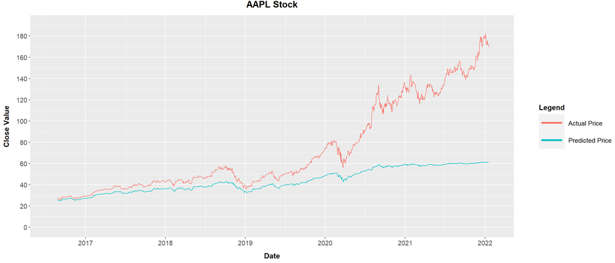

```r
ggplot(aapl[(9001+n_inputs):(9000+n_inputs+dim(pred_test_7)[1]),], aes(x = Date, y = Close, group = 1)) + geom_line(aes(color = "Actual Price")) +
  geom_line(aes(y = pred_test_7, color = "Predicted Price")) +
  labs(x = "Date", y = "Close Value", colour = "Legend") +
  ggtitle("AAPL Stock") +
                        theme(
                        plot.title = element_text(size = 15, face = "bold", hjust = 0.5, vjust = 2.5),
                        axis.title.x = element_text(size = 12, face = "bold", margin = margin(t = 10)),
                        axis.title.y = element_text(size = 12, face = "bold", margin = margin(r = 10)),
                        axis.text.x = element_text(size = 11),
                        axis.text.y = element_text(size = 11),
                        legend.title = element_text(size = 12, face = "bold"),
                        legend.text = element_text(size = 10.5),
                        legend.key.height = unit(1, 'cm'),
                        legend.key.width = unit(1.5, 'cm'),
                        legend.position = "right", legend.margin=margin(l = 30)) +
                        guides(color = guide_legend(override.aes = list(size = 1.5))) +
  scale_x_date(date_breaks = "1 year", date_labels = "%Y", limits = c(as.Date("08/01/16", "%m/%d/%y"),as.Date("02/01/22", "%m/%d/%y"))) +
  scale_y_continuous(breaks = scales::pretty_breaks(n = 10), limits = c(0.00, 190))
```

```r
R2(pred_test_7, aapl$Close[9004:10363])
```

```
##           [,1]
## [1,] 0.9131433
```

## Model 2

### Normalize the Data

Better performance for LSTM

```r
rec_obj_8 <- recipe(Close ~ Close + Date + Adj_Close + Volume, aapl) %>%
    step_log(Close, base = exp(1)) %>%
    step_center(Close) %>%
    step_scale(Close) %>%
    step_log(Adj_Close, base = exp(1)) %>%
    step_center(Adj_Close) %>%
    step_scale(Adj_Close) %>%
    step_log(Volume, base = exp(1)) %>%
    step_center(Volume) %>%
    step_scale(Volume) %>%
    prep()

aapl_normalized_8 <- bake(rec_obj_8, aapl)

#keep centers for denormalization later
center_history_8 <- rec_obj_8$steps[[2]]$means["Close"]
scale_history_8  <- rec_obj_8$steps[[3]]$sds["Close"]

center_history_88 <- rec_obj_8$steps[[5]]$means["Adj_Close"]
scale_history_88  <- rec_obj_8$steps[[6]]$sds["Adj_Close"]

center_history_888 <- rec_obj_8$steps[[8]]$means["Volume"]
scale_history_888  <- rec_obj_8$steps[[9]]$sds["Volume"]

c("center" = center_history_8, "scale" = scale_history_8
  ,"center" = center_history_88, "scale" = scale_history_88
  ,"center" = center_history_888, "scale" = scale_history_888
  )
```

```
##     center.Close      scale.Close center.Adj_Close  scale.Adj_Close
##        0.3908791        2.2317268        0.2336857        2.2887761
##    center.Volume     scale.Volume
##       19.2427217        0.8856951
```

```r
aapl_trn_8 <- aapl_normalized_8[1:8000,] #training
aapl_val_8 <- aapl_normalized_8[8001:9000,] #validation
aapl_test_8 <- aapl_normalized_8[9001:10372,] #test for deletion
```

### Reshaping the Data

```r
n_inputs <- 3 #number of inputs in the RNN e.g. 1st it. use first 10 days to predict the 11th
n_predictions <- 1
batch_size <- 10 #number of batches that you give. large the model is faster -- parmeter
```

### Functions

```r
build_windowed_matrix <- function(data, timesteps) { #tranforms data into the  windows of 4+1) if you have 14K rows this produce a matric of 14K x 5
  t(sapply(1:(length(data) - timesteps + 1), function(x)
    data[x:(x + timesteps - 1)]))
}

reshape_3D <- function(df){ #to do it 14kx5x1 since this is required by keras. If it was multivariate (n) it should be  14kx5xn!!!
  dim(df) <- c(dim(df)[1], dim(df)[2], 1)
  df
}

get_x <- function(mtx, n_inputs, batch_size){#for each row gets the the x's (4 in number)
  mtx <- mtx[, 1:n_inputs]
  mtx <- mtx[1:(nrow(mtx) %/% batch_size * batch_size), ]
  reshape_3D(mtx)
}

get_y <- function(mtx, n_inputs, n_predictions, batch_size) {#for each row gets the the y (5th element) + put them in 3D
  mtx <- mtx[, (n_inputs+1):(n_inputs+n_predictions), drop=FALSE]
  mtx <- mtx[1:(nrow(mtx) %/% batch_size * batch_size), , drop=FALSE]
  if(n_predictions==1){
    dim(mtx) <- c(length(mtx)[1], 1)
  }
  reshape_3D(mtx)
}
```

### Extract ‘Close’ Values

Extract close values and disregard dates

```r
trn_8 <- aapl_trn_8 %>% select(Close) %>% pull() #into  vector
val_8 <- aapl_val_8 %>% select(Close) %>% pull()
test_8 <- aapl_test_8 %>% select(Close) %>% pull()

trn_88 <- aapl_trn_8 %>% select(Adj_Close) %>% pull() #into  vector
val_88 <- aapl_val_8 %>% select(Adj_Close) %>% pull()
test_88 <- aapl_test_8 %>% select(Adj_Close) %>% pull()

trn_888 <- aapl_trn_8 %>% select(Volume) %>% pull() #into  vector
val_888 <- aapl_val_8 %>% select(Volume) %>% pull()
test_888 <- aapl_test_8 %>% select(Volume) %>% pull()
```

### Build matrices

actually using the functions that I defined above

```r
trn_mtx_8 <- build_windowed_matrix(trn_8, n_inputs+n_predictions)
val_mtx_8 <- build_windowed_matrix(val_8, n_inputs+n_predictions)
test_mtx_8 <- build_windowed_matrix(test_8, n_inputs+n_predictions)

trn_mtx_88 <- build_windowed_matrix(trn_88, n_inputs+n_predictions)
val_mtx_88 <- build_windowed_matrix(val_88, n_inputs+n_predictions)
test_mtx_88 <- build_windowed_matrix(test_88, n_inputs+n_predictions)

trn_mtx_888 <- build_windowed_matrix(trn_888, n_inputs+n_predictions)
val_mtx_888 <- build_windowed_matrix(val_888, n_inputs+n_predictions)
test_mtx_888 <- build_windowed_matrix(test_888, n_inputs+n_predictions)

trn_mtx_8888 <- cbind(trn_mtx_8, trn_mtx_88, trn_mtx_888)
val_mtx_8888 <- cbind(val_mtx_8, val_mtx_88, val_mtx_888)
test_mtx_8888 <- cbind(test_mtx_8, test_mtx_88, test_mtx_888)

X_train_8 <- get_x(trn_mtx_8888, n_inputs, batch_size)
Y_train_8 <- get_y(trn_mtx_8888, n_inputs, n_predictions, batch_size)
X_val_8 <- get_x(val_mtx_8888, n_inputs, batch_size)
Y_val_8 <- get_y(val_mtx_8888, n_inputs, n_predictions, batch_size)
X_test_8 <- get_x(test_mtx_8888, n_inputs, batch_size)
Y_test_8 <- get_y(test_mtx_8888, n_inputs, n_predictions, batch_size)
```

### Build model

```r
model_8 <- keras_model_sequential()

model_8 %>%
  layer_simple_rnn(  #rnn with 32 units in each cell
    units = 32,
    batch_input_shape = c(batch_size, n_inputs, 1)
  )

model_8 %>%
  layer_dense(units = 1)

model_8 %>%
  compile(
    loss = 'mean_squared_error',
    optimizer = 'sgd',
    metrics = list("mean_squared_error")
  )
```

```r
callbacks <- list(#stop criterion depends on if the network is not learning any more...stop the model from training after 5 epochs if there is no learning
  callback_early_stopping(patience = 5)
)
```

```r
history_8 <- model_8 %>% fit(
  x = X_train_8,
  y = Y_train_8,
  validation_data = list(X_val_8, Y_val_8),
  batch_size = batch_size,
  epochs = 100,
  callbacks = callbacks
  ,verbose = 0
)
```

### Predictions

```r
pred_test_8 <- model_8 %>%
  predict(X_test_8, batch_size = batch_size)
# de-normalize to original scale
pred_test_8 <- exp((pred_test_8 * scale_history_8 + center_history_8)) #denormalization
```

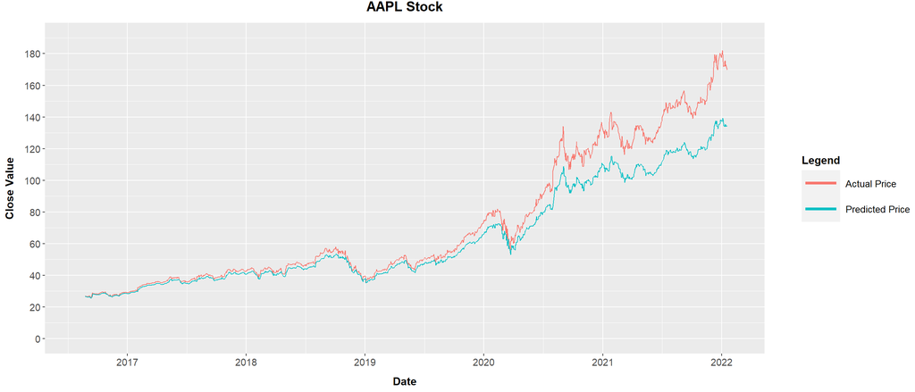

```r
ggplot(aapl[(9001+n_inputs):(9000+n_inputs+dim(pred_test_8)[1]),], aes(x = Date, y = Close, group = 1)) + geom_line(aes(color = "Actual Price")) +
  geom_line(aes(y = pred_test_8, color = "Predicted Price")) +
  labs(x = "Date", y = "Close Value", colour = "Legend") +
  ggtitle("AAPL Stock") +
                        theme(
                        plot.title = element_text(size = 15, face = "bold", hjust = 0.5, vjust = 2.5),
                        axis.title.x = element_text(size = 12, face = "bold", margin = margin(t = 10)),
                        axis.title.y = element_text(size = 12, face = "bold", margin = margin(r = 10)),
                        axis.text.x = element_text(size = 11),
                        axis.text.y = element_text(size = 11),
                        legend.title = element_text(size = 12, face = "bold"),
                        legend.text = element_text(size = 10.5),
                        legend.key.height = unit(1, 'cm'),
                        legend.key.width = unit(1.5, 'cm'),
                        legend.position = "right", legend.margin=margin(l = 30)) +
                        guides(color = guide_legend(override.aes = list(size = 1.5))) +
  scale_x_date(date_breaks = "1 year", date_labels = "%Y", limits = c(as.Date("08/01/16", "%m/%d/%y"),as.Date("02/01/22", "%m/%d/%y"))) +
  scale_y_continuous(breaks = scales::pretty_breaks(n = 10), limits = c(0.00, 190))
```

```r
R2(pred_test_8, aapl$Close[9004:10363])
```

```
##           [,1]
## [1,] 0.9961583
```

## Model 3

### Normalize the Data

Better performance for LSTM

```r
rec_obj_9 <- recipe(Close ~ Close + Date + Adj_Close + High + Low + Volume + Open, aapl) %>%
    step_log(Close, base = exp(1)) %>%
    step_center(Close) %>%
    step_scale(Close) %>%
    step_log(Adj_Close, base = exp(1)) %>%
    step_center(Adj_Close) %>%
    step_scale(Adj_Close) %>%
    step_log(High, base = exp(1)) %>%
    step_center(High) %>%
    step_scale(High) %>%
    step_log(Low, base = exp(1)) %>%
    step_center(Low) %>%
    step_scale(Low) %>%
    step_log(Volume, base = exp(1)) %>%
    step_center(Volume) %>%
    step_scale(Volume) %>%
    step_log(Open, base = exp(1)) %>%
    step_center(Open) %>%
    step_scale(Open) %>%
    prep()

aapl_normalized_9 <- bake(rec_obj_9, aapl)

#keep centers for denormalization later
center_history_9 <- rec_obj_9$steps[[2]]$means["Close"]
scale_history_9  <- rec_obj_9$steps[[3]]$sds["Close"]

center_history_99 <- rec_obj_9$steps[[5]]$means["Adj_Close"]
scale_history_99  <- rec_obj_9$steps[[6]]$sds["Adj_Close"]

center_history_999 <- rec_obj_9$steps[[8]]$means["High"]
scale_history_999  <- rec_obj_9$steps[[9]]$sds["High"]

center_history_9999 <- rec_obj_9$steps[[11]]$means["Low"]
scale_history_9999  <- rec_obj_9$steps[[12]]$sds["Low"]

center_history_99999 <- rec_obj_9$steps[[14]]$means["Volume"]
scale_history_99999  <- rec_obj_9$steps[[15]]$sds["Volume"]

center_history_999999 <- rec_obj_9$steps[[17]]$means["Open"]
scale_history_999999  <- rec_obj_9$steps[[18]]$sds["Open"]

c("center" = center_history_9, "scale" = scale_history_9
  ,"center" = center_history_99, "scale" = scale_history_99
  ,"center" = center_history_999, "scale" = scale_history_999
  ,"center" = center_history_9999, "scale" = scale_history_9999
  ,"center" = center_history_99999, "scale" = scale_history_99999
  ,"center" = center_history_999999, "scale" = scale_history_999999
  )
```

```
##     center.Close      scale.Close center.Adj_Close  scale.Adj_Close
##        0.3908791        2.2317268        0.2336857        2.2887761
##      center.High       scale.High       center.Low        scale.Low
##        0.4066936        2.2280175        0.3751652        2.2342953
##    center.Volume     scale.Volume      center.Open       scale.Open
##       19.2427217        0.8856951        0.3912360        2.2311671
```

```r
aapl_trn_9 <- aapl_normalized_9[1:8000,] #training
aapl_val_9 <- aapl_normalized_9[8001:9000,] #validation
aapl_test_9 <- aapl_normalized_9[9001:10372,] #test for deletion
```

### Reshaping the Data

```r
n_inputs <- 3 #number of inputs in the RNN e.g. 1st it. use first 10 days to predict the 11th
n_predictions <- 1
batch_size <- 10 #number of batches that you give. large the model is faster -- parmeter
```

### Functions

```r
build_windowed_matrix <- function(data, timesteps) { #tranforms data into the  windows of 4+1) if you have 14K rows this produce a matric of 14K x 5
  t(sapply(1:(length(data) - timesteps + 1), function(x)
    data[x:(x + timesteps - 1)]))
}

reshape_3D <- function(df){ #to do it 14kx5x1 since this is required by keras. If it was multivariate (n) it should be  14kx5xn!!!
  dim(df) <- c(dim(df)[1], dim(df)[2], 1)
  df
}

get_x <- function(mtx, n_inputs, batch_size){#for each row gets the the x's (4 in number)
  mtx <- mtx[, 1:n_inputs]
  mtx <- mtx[1:(nrow(mtx) %/% batch_size * batch_size), ]
  reshape_3D(mtx)
}

get_y <- function(mtx, n_inputs, n_predictions, batch_size) {#for each row gets the the y (5th element) + put them in 3D
  mtx <- mtx[, (n_inputs+1):(n_inputs+n_predictions), drop=FALSE]
  mtx <- mtx[1:(nrow(mtx) %/% batch_size * batch_size), , drop=FALSE]
  if(n_predictions==1){
    dim(mtx) <- c(length(mtx)[1], 1)
  }
  reshape_3D(mtx)
}
```

### Extract ‘Close’ Values

Extract close values and disregard dates

```r
trn_9 <- aapl_trn_9 %>% select(Close) %>% pull() #into  vector
val_9 <- aapl_val_9 %>% select(Close) %>% pull()
test_9 <- aapl_test_9 %>% select(Close) %>% pull()

trn_99 <- aapl_trn_9 %>% select(Adj_Close) %>% pull() #into  vector
val_99 <- aapl_val_9 %>% select(Adj_Close) %>% pull()
test_99 <- aapl_test_9 %>% select(Adj_Close) %>% pull()

trn_999 <- aapl_trn_9 %>% select(High) %>% pull() #into  vector
val_999 <- aapl_val_9 %>% select(High) %>% pull()
test_999 <- aapl_test_9 %>% select(High) %>% pull()

trn_9999 <- aapl_trn_9 %>% select(Low) %>% pull() #into  vector
val_9999 <- aapl_val_9 %>% select(Low) %>% pull()
test_9999 <- aapl_test_9 %>% select(Low) %>% pull()

trn_99999 <- aapl_trn_9 %>% select(Volume) %>% pull() #into  vector
val_99999 <- aapl_val_9 %>% select(Volume) %>% pull()
test_99999 <- aapl_test_9 %>% select(Volume) %>% pull()

trn_999999 <- aapl_trn_9 %>% select(Open) %>% pull() #into  vector
val_999999 <- aapl_val_9 %>% select(Open) %>% pull()
test_999999 <- aapl_test_9 %>% select(Open) %>% pull()
```

### Build matrices

actually using the functions that I defined above

```r
trn_mtx_9 <- build_windowed_matrix(trn_9, n_inputs+n_predictions)
val_mtx_9 <- build_windowed_matrix(val_9, n_inputs+n_predictions)
test_mtx_9 <- build_windowed_matrix(test_9, n_inputs+n_predictions)

trn_mtx_99 <- build_windowed_matrix(trn_99, n_inputs+n_predictions)
val_mtx_99 <- build_windowed_matrix(val_99, n_inputs+n_predictions)
test_mtx_99 <- build_windowed_matrix(test_99, n_inputs+n_predictions)

trn_mtx_999 <- build_windowed_matrix(trn_999, n_inputs+n_predictions)
val_mtx_999 <- build_windowed_matrix(val_999, n_inputs+n_predictions)
test_mtx_999 <- build_windowed_matrix(test_999, n_inputs+n_predictions)

trn_mtx_9999 <- build_windowed_matrix(trn_9999, n_inputs+n_predictions)
val_mtx_9999 <- build_windowed_matrix(val_9999, n_inputs+n_predictions)
test_mtx_9999 <- build_windowed_matrix(test_9999, n_inputs+n_predictions)

trn_mtx_99999 <- build_windowed_matrix(trn_99999, n_inputs+n_predictions)
val_mtx_99999 <- build_windowed_matrix(val_99999, n_inputs+n_predictions)
test_mtx_99999 <- build_windowed_matrix(test_99999, n_inputs+n_predictions)

trn_mtx_999999 <- build_windowed_matrix(trn_999999, n_inputs+n_predictions)
val_mtx_999999 <- build_windowed_matrix(val_999999, n_inputs+n_predictions)
test_mtx_999999 <- build_windowed_matrix(test_999999, n_inputs+n_predictions)

trn_mtx_9999999 <- cbind(trn_mtx_9, trn_mtx_99, trn_mtx_999, trn_mtx_9999, trn_mtx_99999, trn_mtx_999999)
val_mtx_9999999 <- cbind(val_mtx_9, val_mtx_99, val_mtx_999, val_mtx_9999, val_mtx_99999, val_mtx_999999)
test_mtx_9999999 <- cbind(test_mtx_9, test_mtx_99, test_mtx_999, test_mtx_9999, test_mtx_99999, test_mtx_999999)

X_train_9 <- get_x(trn_mtx_9999999, n_inputs, batch_size)
Y_train_9 <- get_y(trn_mtx_9999999, n_inputs, n_predictions, batch_size)
X_val_9 <- get_x(val_mtx_9999999, n_inputs, batch_size)
Y_val_9 <- get_y(val_mtx_9999999, n_inputs, n_predictions, batch_size)
X_test_9 <- get_x(test_mtx_9999999, n_inputs, batch_size)
Y_test_9 <- get_y(test_mtx_9999999, n_inputs, n_predictions, batch_size)
```

### Build model

```r
model_9 <- keras_model_sequential()

model_9 %>%
  layer_simple_rnn(  #rnn with 32 units in each cell
    units = 32,
    batch_input_shape = c(batch_size, n_inputs, 1)
  )

model_9 %>%
  layer_dense(units = 1)

model_9 %>%
  compile(
    loss = 'mean_squared_error',
    optimizer = 'sgd',
    metrics = list("mean_squared_error")
  )
```

```r
callbacks <- list(#stop criterion depends on if the network is not learning any more...stop the model from training after 5 epochs if there is no learning
  callback_early_stopping(patience = 5)
)
```

```r
history_9 <- model_9 %>% fit(
  x = X_train_9,
  y = Y_train_9,
  validation_data = list(X_val_9, Y_val_9),
  batch_size = batch_size,
  epochs = 100
  ,callbacks = callbacks
  ,verbose = 0
)
```

### Predictions

```r
pred_test_9 <- model_9 %>%
  predict(X_test_9, batch_size = batch_size)
# de-normalize to original scale
pred_test_9 <- exp((pred_test_9 * scale_history_9 + center_history_9))  #denormalization
```

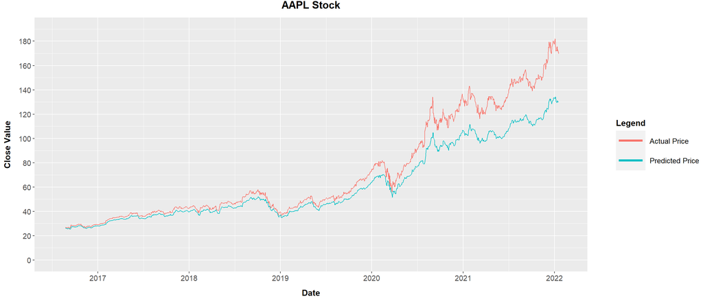

```r
ggplot(aapl[(9001+n_inputs):(9000+n_inputs+dim(pred_test_9)[1]),], aes(x = Date, y = Close, group = 1)) + geom_line(aes(color = "Actual Price")) +
  geom_line(aes(y = pred_test_9, color = "Predicted Price")) +
  labs(x = "Date", y = "Close Value", colour = "Legend") +
  ggtitle("AAPL Stock") +
                        theme(
                        plot.title = element_text(size = 15, face = "bold", hjust = 0.5, vjust = 2.5),
                        axis.title.x = element_text(size = 12, face = "bold", margin = margin(t = 10)),
                        axis.title.y = element_text(size = 12, face = "bold", margin = margin(r = 10)),
                        axis.text.x = element_text(size = 11),
                        axis.text.y = element_text(size = 11),
                        legend.title = element_text(size = 12, face = "bold"),
                        legend.text = element_text(size = 10.5),
                        legend.key.height = unit(1, 'cm'),
                        legend.key.width = unit(1.5, 'cm'),
                        legend.position = "right", legend.margin=margin(l = 30)) +
                        guides(color = guide_legend(override.aes = list(size = 1.5))) +
  scale_x_date(date_breaks = "1 year", date_labels = "%Y", limits = c(as.Date("08/01/16", "%m/%d/%y"),as.Date("02/01/22", "%m/%d/%y"))) +
  scale_y_continuous(breaks = scales::pretty_breaks(n = 10), limits = c(0.00, 190))
```

```r
R2(pred_test_9, aapl$Close[9004:10363])
```

```
##           [,1]
## [1,] 0.9962308
```

```r
comparisons_R2_2 <- as.data.frame(c(R2(pred_test_6, aapl$Close[9004:10363]), R2(pred_test_7, aapl$Close[9004:10363]), R2(pred_test_8, aapl$Close[9004:10363]), R2(pred_test_9, aapl$Close[9004:10363])))

comparisons_RMSE_2 <- as.data.frame(c(RMSE(pred_test_6, aapl$Close[9004:10363]), RMSE(pred_test_7, aapl$Close[9004:10363]), RMSE(pred_test_8, aapl$Close[9004:10363]), RMSE(pred_test_9, aapl$Close[9004:10363])))

comparisons_2 <- cbind(comparisons_R2_2, comparisons_RMSE_2)

comparisons_2$Model = c("Close Price Only", "Close Price, Adj Close Price, & Low", "Close Price, Adj Close Price, & Volume", "Close Price, High, Low, Volume, Adj Close Price, Open Price")
names(comparisons_2)[names(comparisons_2) == "c(R2(pred_test_6, aapl$Close[9004:10363]), R2(pred_test_7, aapl$Close[9004:10363]), R2(pred_test_8, aapl$Close[9004:10363]), R2(pred_test_9, aapl$Close[9004:10363]))"] <- "R_Squared"
names(comparisons_2)[names(comparisons_2) == "c(RMSE(pred_test_6, aapl$Close[9004:10363]), RMSE(pred_test_7, aapl$Close[9004:10363]), RMSE(pred_test_8, aapl$Close[9004:10363]), RMSE(pred_test_9, aapl$Close[9004:10363]))"] <- "RMSE"

comparisons_2 <- comparisons_2[, c(3,1,2)]
comparisons_2 <- comparisons_2[order(comparisons_2$R_Squared, -comparisons_2$RMSE),]

comparisons_2
```

```
##                                                         Model R_Squared
## 2                         Close Price, Adj Close Price, & Low 0.9131433
## 1                                            Close Price Only 0.9247131
## 3                      Close Price, Adj Close Price, & Volume 0.9961583
## 4 Close Price, High, Low, Volume, Adj Close Price, Open Price 0.9962308
##       RMSE
## 2 42.60290
## 1 34.49151
## 3 13.98663
## 4 16.11142
```

# Part 2 (c)

### Normalize the Data

Better performance for LSTM

```r
rec_obj_c <- recipe(Close ~ Close + Date + Adj_Close + High + Low + Volume + Open, aapl) %>%
    step_log(Close, base = exp(1)) %>%
    step_center(Close) %>%
    step_scale(Close) %>%
    step_log(Adj_Close, base = exp(1)) %>%
    step_center(Adj_Close) %>%
    step_scale(Adj_Close) %>%
    step_log(High, base = exp(1)) %>%
    step_center(High) %>%
    step_scale(High) %>%
    step_log(Low, base = exp(1)) %>%
    step_center(Low) %>%
    step_scale(Low) %>%
    step_log(Volume, base = exp(1)) %>%
    step_center(Volume) %>%
    step_scale(Volume) %>%
    step_log(Open, base = exp(1)) %>%
    step_center(Open) %>%
    step_scale(Open) %>%
    prep()

aapl_normalized_c <- bake(rec_obj_c, aapl)

#keep centers for denormalization later
center_history_c <- rec_obj_c$steps[[2]]$means["Close"]
scale_history_c  <- rec_obj_c$steps[[3]]$sds["Close"]

center_history_cc <- rec_obj_c$steps[[5]]$means["Adj_Close"]
scale_history_cc  <- rec_obj_c$steps[[6]]$sds["Adj_Close"]

center_history_ccc <- rec_obj_c$steps[[8]]$means["High"]
scale_history_ccc  <- rec_obj_c$steps[[9]]$sds["High"]

center_history_cccc <- rec_obj_c$steps[[11]]$means["Low"]
scale_history_cccc  <- rec_obj_c$steps[[12]]$sds["Low"]

center_history_ccccc <- rec_obj_c$steps[[14]]$means["Volume"]
scale_history_ccccc  <- rec_obj_c$steps[[15]]$sds["Volume"]

center_history_cccccc <- rec_obj_c$steps[[17]]$means["Open"]
scale_history_cccccc  <- rec_obj_c$steps[[18]]$sds["Open"]

c("center" = center_history_c, "scale" = scale_history_c
  ,"center" = center_history_cc, "scale" = scale_history_cc
  ,"center" = center_history_ccc, "scale" = scale_history_ccc
  ,"center" = center_history_cccc, "scale" = scale_history_cccc
  ,"center" = center_history_ccccc, "scale" = scale_history_ccccc
  ,"center" = center_history_cccccc, "scale" = scale_history_cccccc
  )
```

```
##     center.Close      scale.Close center.Adj_Close  scale.Adj_Close
##        0.3908791        2.2317268        0.2336857        2.2887761
##      center.High       scale.High       center.Low        scale.Low
##        0.4066936        2.2280175        0.3751652        2.2342953
##    center.Volume     scale.Volume      center.Open       scale.Open
##       19.2427217        0.8856951        0.3912360        2.2311671
```

```r
aapl_trn_c <- aapl_normalized_c[1:8000,] #training
aapl_val_c <- aapl_normalized_c[8001:9000,] #validation
aapl_test_c <- aapl_normalized_c[9001:10372,] #test for deletion
```

### Reshaping the Data

```r
n_inputs <- 3 #number of inputs in the RNN e.g. 1st it. use first 10 days to predict the 11th
n_predictions <- 1
batch_size <- 5 #number of batches that you give. large the model is faster -- parmeter
```

### Functions

```r
build_windowed_matrix <- function(data, timesteps) { #tranforms data into the  windows of 4+1) if you have 14K rows this produce a matric of 14K x 5
  t(sapply(1:(length(data) - timesteps + 1), function(x)
    data[x:(x + timesteps - 1)]))
}

reshape_3D <- function(df){ #to do it 14kx5x1 since this is required by keras. If it was multivariate (n) it should be  14kx5xn!!!
  dim(df) <- c(dim(df)[1], dim(df)[2], 1)
  df
}

get_x <- function(mtx, n_inputs, batch_size){#for each row gets the the x's (4 in number)
  mtx <- mtx[, 1:n_inputs]
  mtx <- mtx[1:(nrow(mtx) %/% batch_size * batch_size), ]
  reshape_3D(mtx)
}

get_y <- function(mtx, n_inputs, n_predictions, batch_size) {#for each row gets the the y (5th element) + put them in 3D
  mtx <- mtx[, (n_inputs+1):(n_inputs+n_predictions), drop=FALSE]
  mtx <- mtx[1:(nrow(mtx) %/% batch_size * batch_size), , drop=FALSE]
  if(n_predictions==1){
    dim(mtx) <- c(length(mtx)[1], 1)
  }
  reshape_3D(mtx)
}
```

### Extract ‘Close’ Values

Extract close values and disregard dates

```r
trn_c <- aapl_trn_c %>% select(Close) %>% pull() #into  vector
val_c <- aapl_val_c %>% select(Close) %>% pull()
test_c <- aapl_test_c %>% select(Close) %>% pull()

trn_cc <- aapl_trn_c %>% select(Adj_Close) %>% pull() #into  vector
val_cc <- aapl_val_c %>% select(Adj_Close) %>% pull()
test_cc <- aapl_test_c %>% select(Adj_Close) %>% pull()

trn_ccc <- aapl_trn_c %>% select(High) %>% pull() #into  vector
val_ccc <- aapl_val_c %>% select(High) %>% pull()
test_ccc <- aapl_test_c %>% select(High) %>% pull()

trn_cccc <- aapl_trn_c %>% select(Low) %>% pull() #into  vector
val_cccc <- aapl_val_c %>% select(Low) %>% pull()
test_cccc <- aapl_test_c %>% select(Low) %>% pull()

trn_ccccc <- aapl_trn_c %>% select(Volume) %>% pull() #into  vector
val_ccccc <- aapl_val_c %>% select(Volume) %>% pull()
test_ccccc <- aapl_test_c %>% select(Volume) %>% pull()

trn_cccccc <- aapl_trn_c %>% select(Open) %>% pull() #into  vector
val_cccccc <- aapl_val_c %>% select(Open) %>% pull()
test_cccccc <- aapl_test_c %>% select(Open) %>% pull()
```

### Build matrices

actually using the functions that I defined above

```r
trn_mtx_c <- build_windowed_matrix(trn_c, n_inputs+n_predictions)
val_mtx_c <- build_windowed_matrix(val_c, n_inputs+n_predictions)
test_mtx_c <- build_windowed_matrix(test_c, n_inputs+n_predictions)

trn_mtx_cc <- build_windowed_matrix(trn_cc, n_inputs+n_predictions)
val_mtx_cc <- build_windowed_matrix(val_cc, n_inputs+n_predictions)
test_mtx_cc <- build_windowed_matrix(test_cc, n_inputs+n_predictions)

trn_mtx_ccc <- build_windowed_matrix(trn_ccc, n_inputs+n_predictions)
val_mtx_ccc <- build_windowed_matrix(val_ccc, n_inputs+n_predictions)
test_mtx_ccc <- build_windowed_matrix(test_ccc, n_inputs+n_predictions)

trn_mtx_cccc <- build_windowed_matrix(trn_cccc, n_inputs+n_predictions)
val_mtx_cccc <- build_windowed_matrix(val_cccc, n_inputs+n_predictions)
test_mtx_cccc <- build_windowed_matrix(test_cccc, n_inputs+n_predictions)

trn_mtx_ccccc <- build_windowed_matrix(trn_ccccc, n_inputs+n_predictions)
val_mtx_ccccc <- build_windowed_matrix(val_ccccc, n_inputs+n_predictions)
test_mtx_ccccc <- build_windowed_matrix(test_ccccc, n_inputs+n_predictions)

trn_mtx_cccccc <- build_windowed_matrix(trn_cccccc, n_inputs+n_predictions)
val_mtx_cccccc <- build_windowed_matrix(val_cccccc, n_inputs+n_predictions)
test_mtx_cccccc <- build_windowed_matrix(test_cccccc, n_inputs+n_predictions)

trn_mtx_ccccccc <- cbind(trn_mtx_c, trn_mtx_cc, trn_mtx_ccc, trn_mtx_cccc, trn_mtx_ccccc, trn_mtx_cccccc)
val_mtx_ccccccc <- cbind(val_mtx_c, val_mtx_cc, val_mtx_ccc, val_mtx_cccc, val_mtx_ccccc, val_mtx_cccccc)
test_mtx_ccccccc <- cbind(test_mtx_c, test_mtx_cc, test_mtx_ccc, test_mtx_cccc, test_mtx_ccccc, test_mtx_cccccc)

X_train_c <- get_x(trn_mtx_ccccccc, n_inputs, batch_size)
Y_train_c <- get_y(trn_mtx_ccccccc, n_inputs, n_predictions, batch_size)
X_val_c <- get_x(val_mtx_ccccccc, n_inputs, batch_size)
Y_val_c <- get_y(val_mtx_ccccccc, n_inputs, n_predictions, batch_size)
X_test_c <- get_x(test_mtx_ccccccc, n_inputs, batch_size)
Y_test_c <- get_y(test_mtx_ccccccc, n_inputs, n_predictions, batch_size)
```

### Build model

```r
model_c <- keras_model_sequential()

model_c %>%
  layer_lstm(  #lstm with 32 units in each cell
    units = 256,
    batch_input_shape = c(batch_size, n_inputs, 1)
  )

model_c %>%
  layer_dense(units = 1)

model_c %>%
  compile(
    loss = 'mean_squared_error',
    optimizer = 'sgd',
    metrics = list("mean_squared_error")
  )
```

```r
callbacks <- list(#stop criterion depends on if the network is not learning any more...stop the model from training after 5 epochs if there is no learning
  callback_early_stopping(patience = 5)
)
```

```r
history_c <- model_c %>% fit(
  x = X_train_c,
  y = Y_train_c,
  validation_data = list(X_val_c, Y_val_c),
  batch_size = batch_size,
  epochs = 250
  #,callbacks = callbacks
  ,verbose = 0
)
```

### Predictions

```r
pred_test_c <- model_c %>%
  predict(X_test_c, batch_size = batch_size)
# de-normalize to original scale
pred_test_c <- exp((pred_test_c * scale_history_c + center_history_c))  #denormalization
```

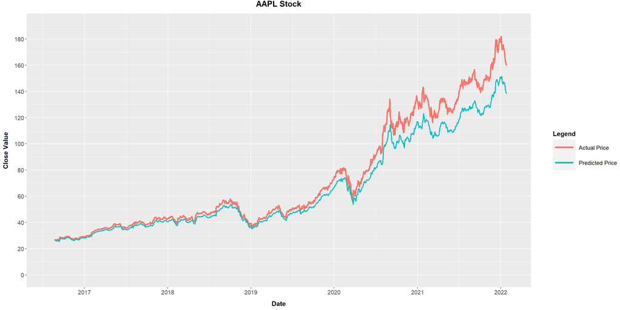

```r
ggplot(aapl[(9001+n_inputs):(9000+n_inputs+dim(pred_test_c)[1]),], aes(x = Date, y = Close, group = 1)) + geom_line(aes(color = "Actual Price"), size = 1.25) +
  geom_line(aes(y = pred_test_c, color = "Predicted Price"), size = 1) +
  labs(x = "Date", y = "Close Value", colour = "Legend") +
  ggtitle("AAPL Stock") +
                        theme(
                        plot.title = element_text(size = 15, face = "bold", hjust = 0.5, vjust = 2.5),
                        axis.title.x = element_text(size = 12, face = "bold", margin = margin(t = 10)),
                        axis.title.y = element_text(size = 12, face = "bold", margin = margin(r = 10)),
                        axis.text.x = element_text(size = 11),
                        axis.text.y = element_text(size = 11),
                        legend.title = element_text(size = 12, face = "bold"),
                        legend.text = element_text(size = 10.5),
                        legend.key.height = unit(1, 'cm'),
                        legend.key.width = unit(1.5, 'cm'),
                        legend.position = "right", legend.margin=margin(l = 30)) +
                        guides(color = guide_legend(override.aes = list(size = 1.5))) +
  scale_x_date(date_breaks = "1 year", date_labels = "%Y", limits = c(as.Date("08/01/16", "%m/%d/%y"),as.Date("02/01/22", "%m/%d/%y"))) +
  scale_y_continuous(breaks = scales::pretty_breaks(n = 10), limits = c(0.00, 190))
```

```r
R2(pred_test_c, aapl$Close[9004:10368])
```

```
##           [,1]
## [1,] 0.9977706
```

```r
comparisons_R2_3 <- as.data.frame(c(R2(pred_test_5, aapl$Close[9004:10363]), R2(pred_test_c, aapl$Close[9004:10368])))

comparisons_RMSE_3 <- as.data.frame(c(RMSE(pred_test_5, aapl$Close[9004:10363]), RMSE(pred_test_c, aapl$Close[9004:10368])))

comparisons_3 <- cbind(comparisons_R2_3, comparisons_RMSE_3)

comparisons_3$Model = c("Untuned LSTM", "Tuned LSTM")
names(comparisons_3)[names(comparisons_3) == "c(R2(pred_test_5, aapl$Close[9004:10363]), R2(pred_test_c, aapl$Close[9004:10368]))"] <- "R_Squared"
names(comparisons_3)[names(comparisons_3) == "c(RMSE(pred_test_5, aapl$Close[9004:10363]), RMSE(pred_test_c, aapl$Close[9004:10368]))"] <- "RMSE"

comparisons_3 <- comparisons_3[, c(3,1,2)]

comparisons_3
```

```
##          Model R_Squared     RMSE
## 1 Untuned LSTM 0.9783324 46.44875
## 2   Tuned LSTM 0.9977706 10.51505
```

# Part 2 (d)

### Normalize the Data

Better performance for LSTM

```r
rec_obj_d <- recipe(Close ~ Close + Date + Adj_Close + High + Low + Volume + Open, aapl) %>%
    step_log(Close, base = exp(1)) %>%
    step_center(Close) %>%
    step_scale(Close) %>%
    step_log(Adj_Close, base = exp(1)) %>%
    step_center(Adj_Close) %>%
    step_scale(Adj_Close) %>%
    step_log(High, base = exp(1)) %>%
    step_center(High) %>%
    step_scale(High) %>%
    step_log(Low, base = exp(1)) %>%
    step_center(Low) %>%
    step_scale(Low) %>%
    step_log(Volume, base = exp(1)) %>%
    step_center(Volume) %>%
    step_scale(Volume) %>%
    step_log(Open, base = exp(1)) %>%
    step_center(Open) %>%
    step_scale(Open) %>%
    prep()

aapl_normalized_d <- bake(rec_obj_d, aapl)

#keep centers for denormalization later
center_history_d <- rec_obj_d$steps[[2]]$means["Close"]
scale_history_d  <- rec_obj_d$steps[[3]]$sds["Close"]

center_history_dd <- rec_obj_d$steps[[5]]$means["Adj_Close"]
scale_history_dd  <- rec_obj_d$steps[[6]]$sds["Adj_Close"]

center_history_ddd <- rec_obj_d$steps[[8]]$means["High"]
scale_history_ddd  <- rec_obj_d$steps[[9]]$sds["High"]

center_history_dddd <- rec_obj_d$steps[[11]]$means["Low"]
scale_history_dddd  <- rec_obj_d$steps[[12]]$sds["Low"]

center_history_ddddd <- rec_obj_d$steps[[14]]$means["Volume"]
scale_history_ddddd  <- rec_obj_d$steps[[15]]$sds["Volume"]

center_history_dddddd <- rec_obj_d$steps[[17]]$means["Open"]
scale_history_dddddd  <- rec_obj_d$steps[[18]]$sds["Open"]

c("center" = center_history_d, "scale" = scale_history_d
  ,"center" = center_history_dd, "scale" = scale_history_dd
  ,"center" = center_history_ddd, "scale" = scale_history_ddd
  ,"center" = center_history_dddd, "scale" = scale_history_dddd
  ,"center" = center_history_ddddd, "scale" = scale_history_ddddd
  ,"center" = center_history_dddddd, "scale" = scale_history_dddddd
  )
```

```
##     center.Close      scale.Close center.Adj_Close  scale.Adj_Close
##        0.3908791        2.2317268        0.2336857        2.2887761
##      center.High       scale.High       center.Low        scale.Low
##        0.4066936        2.2280175        0.3751652        2.2342953
##    center.Volume     scale.Volume      center.Open       scale.Open
##       19.2427217        0.8856951        0.3912360        2.2311671
```

```r
aapl_trn_d <- aapl_normalized_d[1:8000,] #training
aapl_val_d <- aapl_normalized_d[8001:9000,] #validation
aapl_test_d <- aapl_normalized_d[9001:10372,] #test for deletion
```

### Reshaping the Data

```r
n_inputs <- 3 #number of inputs in the RNN e.g. 1st it. use first 10 days to predict the 11th
n_predictions <- 1
batch_size <- 5 #number of batches that you give. large the model is faster -- parmeter
```

### Functions

```r
build_windowed_matrix <- function(data, timesteps) { #tranforms data into the  windows of 4+1) if you have 14K rows this produce a matric of 14K x 5
  t(sapply(1:(length(data) - timesteps + 1), function(x)
    data[x:(x + timesteps - 1)]))
}

reshape_3D <- function(df){ #to do it 14kx5x1 since this is required by keras. If it was multivariate (n) it should be  14kx5xn!!!
  dim(df) <- c(dim(df)[1], dim(df)[2], 1)
  df
}

get_x <- function(mtx, n_inputs, batch_size){#for each row gets the the x's (4 in number)
  mtx <- mtx[, 1:n_inputs]
  mtx <- mtx[1:(nrow(mtx) %/% batch_size * batch_size), ]
  reshape_3D(mtx)
}

get_y <- function(mtx, n_inputs, n_predictions, batch_size) {#for each row gets the the y (5th element) + put them in 3D
  mtx <- mtx[, (n_inputs+1):(n_inputs+n_predictions), drop=FALSE]
  mtx <- mtx[1:(nrow(mtx) %/% batch_size * batch_size), , drop=FALSE]
  if(n_predictions==1){
    dim(mtx) <- c(length(mtx)[1], 1)
  }
  reshape_3D(mtx)
}
```

### Extract ‘Close’ Values

Extract close values and disregard dates

```r
trn_d <- aapl_trn_d %>% select(Close) %>% pull() #into  vector
val_d <- aapl_val_d %>% select(Close) %>% pull()
test_d <- aapl_test_d %>% select(Close) %>% pull()

trn_dd <- aapl_trn_d %>% select(Adj_Close) %>% pull() #into  vector
val_dd <- aapl_val_d %>% select(Adj_Close) %>% pull()
test_dd <- aapl_test_d %>% select(Adj_Close) %>% pull()

trn_ddd <- aapl_trn_d %>% select(High) %>% pull() #into  vector
val_ddd <- aapl_val_d %>% select(High) %>% pull()
test_ddd <- aapl_test_d %>% select(High) %>% pull()

trn_dddd <- aapl_trn_d %>% select(Low) %>% pull() #into  vector
val_dddd <- aapl_val_d %>% select(Low) %>% pull()
test_dddd <- aapl_test_d %>% select(Low) %>% pull()

trn_ddddd <- aapl_trn_d %>% select(Volume) %>% pull() #into  vector
val_ddddd <- aapl_val_d %>% select(Volume) %>% pull()
test_ddddd <- aapl_test_d %>% select(Volume) %>% pull()

trn_dddddd <- aapl_trn_d %>% select(Open) %>% pull() #into  vector
val_dddddd <- aapl_val_d %>% select(Open) %>% pull()
test_dddddd <- aapl_test_d %>% select(Open) %>% pull()
```

### Build matrices

actually using the functions that I defined above

```r
trn_mtx_d <- build_windowed_matrix(trn_d, n_inputs+n_predictions)
val_mtx_d <- build_windowed_matrix(val_d, n_inputs+n_predictions)
test_mtx_d <- build_windowed_matrix(test_d, n_inputs+n_predictions)

trn_mtx_dd <- build_windowed_matrix(trn_dd, n_inputs+n_predictions)
val_mtx_dd <- build_windowed_matrix(val_dd, n_inputs+n_predictions)
test_mtx_dd <- build_windowed_matrix(test_dd, n_inputs+n_predictions)

trn_mtx_ddd <- build_windowed_matrix(trn_ddd, n_inputs+n_predictions)
val_mtx_ddd <- build_windowed_matrix(val_ddd, n_inputs+n_predictions)
test_mtx_ddd <- build_windowed_matrix(test_ddd, n_inputs+n_predictions)

trn_mtx_dddd <- build_windowed_matrix(trn_dddd, n_inputs+n_predictions)
val_mtx_dddd <- build_windowed_matrix(val_dddd, n_inputs+n_predictions)
test_mtx_dddd <- build_windowed_matrix(test_dddd, n_inputs+n_predictions)

trn_mtx_ddddd <- build_windowed_matrix(trn_ddddd, n_inputs+n_predictions)
val_mtx_ddddd <- build_windowed_matrix(val_ddddd, n_inputs+n_predictions)
test_mtx_ddddd <- build_windowed_matrix(test_ddddd, n_inputs+n_predictions)

trn_mtx_dddddd <- build_windowed_matrix(trn_dddddd, n_inputs+n_predictions)
val_mtx_dddddd <- build_windowed_matrix(val_dddddd, n_inputs+n_predictions)
test_mtx_dddddd <- build_windowed_matrix(test_dddddd, n_inputs+n_predictions)

trn_mtx_ddddddd <- cbind(trn_mtx_d, trn_mtx_dd, trn_mtx_ddd, trn_mtx_dddd, trn_mtx_ddddd, trn_mtx_dddddd)
val_mtx_ddddddd <- cbind(val_mtx_d, val_mtx_dd, val_mtx_ddd, val_mtx_dddd, val_mtx_ddddd, val_mtx_dddddd)
test_mtx_ddddddd <- cbind(test_mtx_d, test_mtx_dd, test_mtx_ddd, test_mtx_dddd, test_mtx_ddddd, test_mtx_dddddd)

X_train_d <- get_x(trn_mtx_ddddddd, n_inputs, batch_size)
Y_train_d <- get_y(trn_mtx_ddddddd, n_inputs, n_predictions, batch_size)
X_val_d <- get_x(val_mtx_ddddddd, n_inputs, batch_size)
Y_val_d <- get_y(val_mtx_ddddddd, n_inputs, n_predictions, batch_size)
X_test_d <- get_x(test_mtx_ddddddd, n_inputs, batch_size)
Y_test_d <- get_y(test_mtx_ddddddd, n_inputs, n_predictions, batch_size)
```

### Build model

```r
model_d <- keras_model_sequential()

model_d %>%
  layer_simple_rnn(  #rnn with 32 units in each cell
    units = 256,
    batch_input_shape = c(batch_size, n_inputs, 1)
  )

model_d %>%
  layer_dense(units = 1)

model_d %>%
  compile(
    loss = 'mean_squared_error',
    optimizer = 'sgd',
    metrics = list("mean_squared_error")
  )
```

```r
callbacks <- list(#stop criterion depends on if the network is not learning any more...stop the model from training after 5 epochs if there is no learning
  callback_early_stopping(patience = 5)
)
```

```r
history_d <- model_d %>% fit(
  x = X_train_d,
  y = Y_train_d,
  validation_data = list(X_val_d, Y_val_d),
  batch_size = batch_size,
  epochs = 250
  #,callbacks = callbacks
  ,verbose = 0
)
```

### Predictions

```r
pred_test_d <- model_d %>%
  predict(X_test_d, batch_size = batch_size)
# de-normalize to original scale
pred_test_d <- exp((pred_test_d * scale_history_d + center_history_d))  #denormalization
```

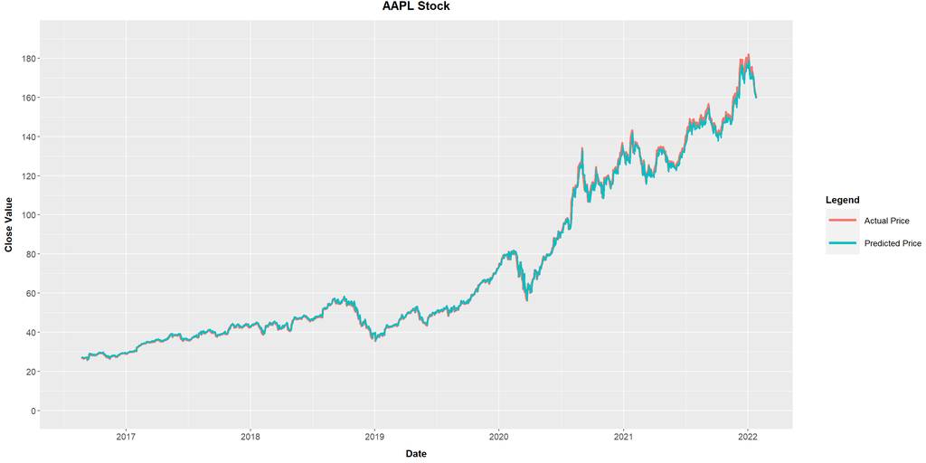

```r
ggplot(aapl[(9001+n_inputs):(9000+n_inputs+dim(pred_test_d)[1]),], aes(x = Date, y = Close, group = 1)) + geom_line(aes(color = "Actual Price"), size = 1.25) +
  geom_line(aes(y = pred_test_d, color = "Predicted Price"), size = 1) +
  labs(x = "Date", y = "Close Value", colour = "Legend") +
  ggtitle("AAPL Stock") +
                        theme(
                        plot.title = element_text(size = 15, face = "bold", hjust = 0.5, vjust = 2.5),
                        axis.title.x = element_text(size = 12, face = "bold", margin = margin(t = 10)),
                        axis.title.y = element_text(size = 12, face = "bold", margin = margin(r = 10)),
                        axis.text.x = element_text(size = 11),
                        axis.text.y = element_text(size = 11),
                        legend.title = element_text(size = 12, face = "bold"),
                        legend.text = element_text(size = 10.5),
                        legend.key.height = unit(1, 'cm'),
                        legend.key.width = unit(1.5, 'cm'),
                        legend.position = "right", legend.margin=margin(l = 30)) +
                        guides(color = guide_legend(override.aes = list(size = 1.5))) +
  scale_x_date(date_breaks = "1 year", date_labels = "%Y", limits = c(as.Date("08/01/16", "%m/%d/%y"),as.Date("02/01/22", "%m/%d/%y"))) +
  scale_y_continuous(breaks = scales::pretty_breaks(n = 10), limits = c(0.00, 190))
```

```r
R2(pred_test_d, aapl$Close[9004:10368])
```

```
##           [,1]
## [1,] 0.9985557
```

```r
comparisons_R2_4 <- as.data.frame(c(R2(pred_test_9, aapl$Close[9004:10363]), R2(pred_test_d, aapl$Close[9004:10368])))

comparisons_RMSE_4 <- as.data.frame(c(RMSE(pred_test_9, aapl$Close[9004:10363]), RMSE(pred_test_d, aapl$Close[9004:10368])))

comparisons_4 <- cbind(comparisons_R2_4, comparisons_RMSE_4)

comparisons_4$Model = c("Untuned RNN", "Tuned RNN")
names(comparisons_4)[names(comparisons_4) == "c(R2(pred_test_9, aapl$Close[9004:10363]), R2(pred_test_d, aapl$Close[9004:10368]))"] <- "R_Squared"
names(comparisons_4)[names(comparisons_4) == "c(RMSE(pred_test_9, aapl$Close[9004:10363]), RMSE(pred_test_d, aapl$Close[9004:10368]))"] <- "RMSE"

comparisons_4 <- comparisons_4[, c(3,1,2)]

comparisons_4
```

```
##         Model R_Squared      RMSE
## 1 Untuned RNN 0.9962308 16.111422
## 2   Tuned RNN 0.9985557  1.777648
```

# PART 2 (e)

### Normalize the Data

Better performance for LSTM

```r
rec_obj_e <- recipe(Close ~ Close + Date + Adj_Close + High + Low + Volume + Open, aapl) %>%
    step_log(Close, base = exp(1)) %>%
    step_center(Close) %>%
    step_scale(Close) %>%
    step_log(Adj_Close, base = exp(1)) %>%
    step_center(Adj_Close) %>%
    step_scale(Adj_Close) %>%
    step_log(High, base = exp(1)) %>%
    step_center(High) %>%
    step_scale(High) %>%
    step_log(Low, base = exp(1)) %>%
    step_center(Low) %>%
    step_scale(Low) %>%
    step_log(Volume, base = exp(1)) %>%
    step_center(Volume) %>%
    step_scale(Volume) %>%
    step_log(Open, base = exp(1)) %>%
    step_center(Open) %>%
    step_scale(Open) %>%
    prep()

aapl_normalized_e <- bake(rec_obj_e, aapl)

#keep centers for denormalization later
center_history_e <- rec_obj_e$steps[[2]]$means["Close"]
scale_history_e  <- rec_obj_e$steps[[3]]$sds["Close"]

center_history_ee <- rec_obj_e$steps[[5]]$means["Adj_Close"]
scale_history_ee  <- rec_obj_e$steps[[6]]$sds["Adj_Close"]

center_history_eee <- rec_obj_e$steps[[8]]$means["High"]
scale_history_eee  <- rec_obj_e$steps[[9]]$sds["High"]

center_history_eeee <- rec_obj_e$steps[[11]]$means["Low"]
scale_history_eeee  <- rec_obj_e$steps[[12]]$sds["Low"]

center_history_eeeee <- rec_obj_e$steps[[14]]$means["Volume"]
scale_history_eeeee  <- rec_obj_e$steps[[15]]$sds["Volume"]

center_history_eeeeee <- rec_obj_e$steps[[17]]$means["Open"]
scale_history_eeeeee  <- rec_obj_e$steps[[18]]$sds["Open"]

c("center" = center_history_e, "scale" = scale_history_e
  ,"center" = center_history_ee, "scale" = scale_history_ee
  ,"center" = center_history_eee, "scale" = scale_history_eee
  ,"center" = center_history_eeee, "scale" = scale_history_eeee
  ,"center" = center_history_eeeee, "scale" = scale_history_eeeee
  ,"center" = center_history_eeeeee, "scale" = scale_history_eeeeee
  )
```

```
##     center.Close      scale.Close center.Adj_Close  scale.Adj_Close
##        0.3908791        2.2317268        0.2336857        2.2887761
##      center.High       scale.High       center.Low        scale.Low
##        0.4066936        2.2280175        0.3751652        2.2342953
##    center.Volume     scale.Volume      center.Open       scale.Open
##       19.2427217        0.8856951        0.3912360        2.2311671
```

```r
aapl_trn_e <- aapl_normalized_e[1:8000,] #training
aapl_val_e <- aapl_normalized_e[8001:9000,] #validation
aapl_test_e <- aapl_normalized_e[9001:10372,] #test for deletion
```

### Reshaping the Data

```r
n_inputs <- 7 #number of inputs in the RNN e.g. 1st it. use first 10 days to predict the 11th
n_predictions <- 2
batch_size <- 10 #number of batches that you give. large the model is faster -- parmeter
```

### Functions

```r
build_windowed_matrix <- function(data, timesteps) { #tranforms data into the  windows of 4+1) if you have 14K rows this produce a matric of 14K x 5
  t(sapply(1:(length(data) - timesteps + 1), function(x)
    data[x:(x + timesteps - 1)]))
}

reshape_3D <- function(df){ #to do it 14kx5x1 since this is required by keras. If it was multivariate (n) it should be  14kx5xn!!!
  dim(df) <- c(dim(df)[1], dim(df)[2], 1)
  df
}

get_x <- function(mtx, n_inputs, batch_size){#for each row gets the the x's (4 in number)
  mtx <- mtx[, 1:n_inputs]
  mtx <- mtx[1:(nrow(mtx) %/% batch_size * batch_size), ]
  reshape_3D(mtx)
}

get_y <- function(mtx, n_inputs, n_predictions, batch_size) {#for each row gets the the y (5th element) + put them in 3D
  mtx <- mtx[, (n_inputs+1):(n_inputs+n_predictions), drop=FALSE]
  mtx <- mtx[1:(nrow(mtx) %/% batch_size * batch_size), , drop=FALSE]
  if(n_predictions==1){
    dim(mtx) <- c(length(mtx)[1], 1)
  }
  reshape_3D(mtx)
}
```

### Extract ‘Close’ Values

Extract close values and disregard dates

```r
trn_e <- aapl_trn_e %>% select(Close) %>% pull() #into  vector
val_e <- aapl_val_e %>% select(Close) %>% pull()
test_e <- aapl_test_e %>% select(Close) %>% pull()

trn_ee <- aapl_trn_e %>% select(Adj_Close) %>% pull() #into  vector
val_ee <- aapl_val_e %>% select(Adj_Close) %>% pull()
test_ee <- aapl_test_e %>% select(Adj_Close) %>% pull()

trn_eee <- aapl_trn_e %>% select(High) %>% pull() #into  vector
val_eee <- aapl_val_e %>% select(High) %>% pull()
test_eee <- aapl_test_e %>% select(High) %>% pull()

trn_eeee <- aapl_trn_e %>% select(Low) %>% pull() #into  vector
val_eeee <- aapl_val_e %>% select(Low) %>% pull()
test_eeee <- aapl_test_e %>% select(Low) %>% pull()

trn_eeeee <- aapl_trn_e %>% select(Volume) %>% pull() #into  vector
val_eeeee <- aapl_val_e %>% select(Volume) %>% pull()
test_eeeee <- aapl_test_e %>% select(Volume) %>% pull()

trn_eeeeee <- aapl_trn_e %>% select(Open) %>% pull() #into  vector
val_eeeeee <- aapl_val_e %>% select(Open) %>% pull()
test_eeeeee <- aapl_test_e %>% select(Open) %>% pull()
```

### Build matrices

actually using the functions that I defined above

```r
trn_mtx_e <- build_windowed_matrix(trn_e, n_inputs+n_predictions)
val_mtx_e <- build_windowed_matrix(val_e, n_inputs+n_predictions)
test_mtx_e <- build_windowed_matrix(test_e, n_inputs+n_predictions)

trn_mtx_ee <- build_windowed_matrix(trn_ee, n_inputs+n_predictions)
val_mtx_ee <- build_windowed_matrix(val_ee, n_inputs+n_predictions)
test_mtx_ee <- build_windowed_matrix(test_ee, n_inputs+n_predictions)

trn_mtx_eee <- build_windowed_matrix(trn_eee, n_inputs+n_predictions)
val_mtx_eee <- build_windowed_matrix(val_eee, n_inputs+n_predictions)
test_mtx_eee <- build_windowed_matrix(test_eee, n_inputs+n_predictions)

trn_mtx_eeee <- build_windowed_matrix(trn_eeee, n_inputs+n_predictions)
val_mtx_eeee <- build_windowed_matrix(val_eeee, n_inputs+n_predictions)
test_mtx_eeee <- build_windowed_matrix(test_eeee, n_inputs+n_predictions)

trn_mtx_eeeee <- build_windowed_matrix(trn_eeeee, n_inputs+n_predictions)
val_mtx_eeeee <- build_windowed_matrix(val_eeeee, n_inputs+n_predictions)
test_mtx_eeeee <- build_windowed_matrix(test_eeeee, n_inputs+n_predictions)

trn_mtx_eeeeee <- build_windowed_matrix(trn_eeeeee, n_inputs+n_predictions)
val_mtx_eeeeee <- build_windowed_matrix(val_eeeeee, n_inputs+n_predictions)
test_mtx_eeeeee <- build_windowed_matrix(test_eeeeee, n_inputs+n_predictions)

trn_mtx_eeeeeee <- cbind(trn_mtx_e, trn_mtx_ee, trn_mtx_eee, trn_mtx_eeee, trn_mtx_eeeee, trn_mtx_eeeeee)
val_mtx_eeeeeee <- cbind(val_mtx_e, val_mtx_ee, val_mtx_eee, val_mtx_eeee, val_mtx_eeeee, val_mtx_eeeeee)
test_mtx_eeeeeee <- cbind(test_mtx_e, test_mtx_ee, test_mtx_eee, test_mtx_eeee, test_mtx_eeeee, test_mtx_eeeeee)

X_train_e <- get_x(trn_mtx_eeeeeee, n_inputs, batch_size)
Y_train_e <- get_y(trn_mtx_eeeeeee, n_inputs, n_predictions, batch_size)
X_val_e <- get_x(val_mtx_eeeeeee, n_inputs, batch_size)
Y_val_e <- get_y(val_mtx_eeeeeee, n_inputs, n_predictions, batch_size)
X_test_e <- get_x(test_mtx_eeeeeee, n_inputs, batch_size)
Y_test_e <- get_y(test_mtx_eeeeeee, n_inputs, n_predictions, batch_size)
```

### Build model

```r
model_e <- keras_model_sequential()

model_e %>%
  layer_simple_rnn(  #rnn with 32 units in each cell
    units = 128,
    batch_input_shape = c(batch_size, n_inputs, 1)
  )

model_e %>%
  layer_dense(units = 2)

model_e %>%
  compile(
    loss = 'mean_squared_error',
    optimizer = 'sgd',
    metrics = list("mean_squared_error")
  )
```

```r
callbacks <- list(#stop criterion depends on if the network is not learning any more...stop the model from training after 5 epochs if there is no learning
  callback_early_stopping(patience = 5)
)
```

```r
history_e <- model_e %>% fit(
  x = X_train_e,
  y = Y_train_e,
  validation_data = list(X_val_e, Y_val_e),
  batch_size = batch_size,
  epochs = 200
  #,callbacks = callbacks
  ,verbose = 0
)
```

### Predictions

```r
pred_test_e <- model_e %>%
  predict(X_test_e, batch_size = batch_size)
# de-normalize to original scale
pred_test_e <- exp((pred_test_e * scale_history_e + center_history_e))  #denormalization
```

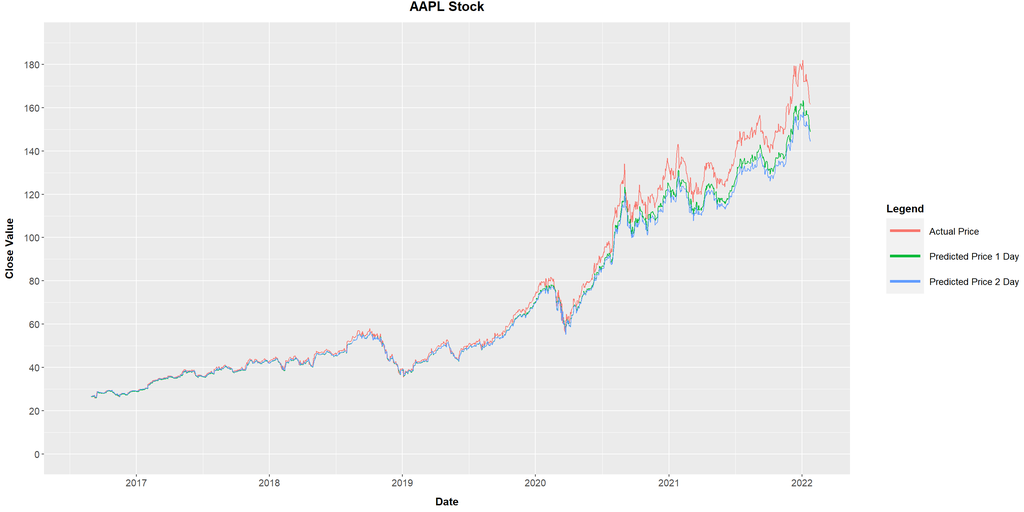

```r
ggplot(aapl[(9001+n_inputs):(9000+n_inputs+nrow(pred_test_e)),], aes(x = Date, y = Close, group = 1)) + geom_line(aes(color = "Actual Price")) +
  geom_line(aes(y = pred_test_e[, 1], color = "Predicted Price 1 Day")) +
  geom_line(aes(y = pred_test_e[, 2], color = "Predicted Price 2 Day")) +
  labs(x = "Date", y = "Close Value", colour = "Legend") +
  ggtitle("AAPL Stock") +
                        theme(
                        plot.title = element_text(size = 15, face = "bold", hjust = 0.5, vjust = 2.5),
                        axis.title.x = element_text(size = 12, face = "bold", margin = margin(t = 10)),
                        axis.title.y = element_text(size = 12, face = "bold", margin = margin(r = 10)),
                        axis.text.x = element_text(size = 11),
                        axis.text.y = element_text(size = 11),
                        legend.title = element_text(size = 12, face = "bold"),
                        legend.text = element_text(size = 10.5),
                        legend.key.height = unit(1, 'cm'),
                        legend.key.width = unit(1.5, 'cm'),
                        legend.position = "right", legend.margin=margin(l = 30)) +
                        guides(color = guide_legend(override.aes = list(size = 1.5))) +
  scale_x_date(date_breaks = "1 year", date_labels = "%Y", limits = c(as.Date("08/01/16", "%m/%d/%y"),as.Date("02/01/22", "%m/%d/%y"))) +
  scale_y_continuous(breaks = scales::pretty_breaks(n = 10), limits = c(0.00, 190))
```

```r
comparisons_5 <- as.data.frame(c(R2(pred_test_e[,1], aapl$Close[9008:10367]), RMSE(pred_test_e[,1], aapl$Close[9008:10367])))

comparisons_55 <- as.data.frame(c(R2(pred_test_e[,2], aapl$Close[9008:10367]), RMSE(pred_test_e[,2], aapl$Close[9008:10367])))

comparisons_5$Metric = c("R Squared", "RMSE")
names(comparisons_5)[names(comparisons_5) == "c(R2(pred_test_e[, 1], aapl$Close[9008:10367]), RMSE(pred_test_e[, 1], aapl$Close[9008:10367]))"] <- "Value"
comparisons_5 <- comparisons_5[, c(2,1)]
comparisons_5 <- as.data.frame(t(comparisons_5))
rownames(comparisons_5) <- c()
comparisons_5 <- comparisons_5[-1,]
names(comparisons_5)[names(comparisons_5) == "V1"] <- "R Squared"
names(comparisons_5)[names(comparisons_5) == "V2"] <- "RMSE"
comparisons_5 <- comparisons_5 %>%
  add_column(Model = c("Predicted Price 1 Day"))
comparisons_5 <- comparisons_5[, c(3,1,2)]


comparisons_55$Metric = c("R Squared", "RMSE")
names(comparisons_55)[names(comparisons_55) == "c(R2(pred_test_e[, 2], aapl$Close[9008:10367]), RMSE(pred_test_e[, 2], aapl$Close[9008:10367]))"] <- "Value"
comparisons_55 <- comparisons_55[, c(2,1)]
comparisons_55 <- as.data.frame(t(comparisons_55))
rownames(comparisons_55) <- c()
comparisons_55 <- comparisons_55[-1,]
names(comparisons_55)[names(comparisons_55) == "V1"] <- "R Squared"
names(comparisons_55)[names(comparisons_55) == "V2"] <- "RMSE"
comparisons_55 <- comparisons_55 %>%
  add_column(Model = c("Predicted Price 2 Day"))
comparisons_55 <- comparisons_55[, c(3,1,2)]

comparisons_555 <- rbind(comparisons_5, comparisons_55)

comparisons_555
```

```
##                    Model R Squared      RMSE
## 2  Predicted Price 1 Day 0.9982128 5.9494194
## 21 Predicted Price 2 Day 0.9978712 7.5271178
```